# Analysis on Human Development Index

#### [Fall 2023: DATA 604- L01]

##### Group #7

##### Prashant Dhungana-30080130

##### Prateek Kaushik-30229287

##### Mariya Mathews-30192182

##### Nisha Pillai-30158934

##### Arteen Rafiei-30043409

# Introduction

The chosen subject matter of this project revolves around the analysis of Human Development Index (HDI) and its relationship with various societal factors. The HDI is a summary measure of human development that was introduced in 1990 by the United Nations Development Programme (UNDP) [1]. The UNDP evaluates and ranks countries based on three fundamental dimensions of human development: longevity, education and standard of living. Longevity is measured by life expectancy at birth, reflecting the overall health and longevity of a nation's population. The education dimension is measured through two metrics: expected years of schooling for children entering schools and the mean years of schooling for the adult population. The standard of living is measured using the Gross National Income (GNI) per capita. The purpose of this project is to uncover insights into how different aspects of human development interact with one another and to understand how countries' development is affected by a combination of factors, including gender inequality and environmental pressures. The motivation of this project is to understand changing trends in HDI, investigate gender disparities and their impact on development, and assess the environmental pressures affecting human development. Through this exploration, we aim to generate valuable insights that can inform policymakers, researchers, and society at large.

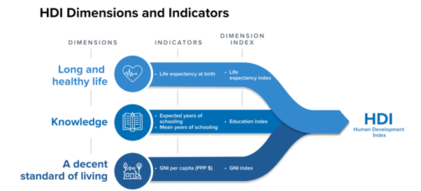

# Motivation

Our motivation emanates from a profound curiosity about the evolving face of human development and the myriad forces that influence it. As we witness a dynamic global landscape, characterized by demographic shifts, technological revolutions, and heightened environmental awareness, the need to comprehend the nuanced intricacies of development becomes imperative. Through our exploration of HDI trends, gender disparities, and environmental impacts, we seek not only to understand but also to contribute to the ongoing dialogue that shapes the policies and frameworks guiding societies worldwide.

In addressing gender-based inequities and environmental challenges, our motivation extends beyond mere analysis. It is a call to action, an invitation to stakeholders and decision-makers to leverage these insights for the betterment of communities and the sustainable progression of our shared global future.

# Datasets

The dataset is extracted directly from the official website of the United Nations Development Programme (UNDP) [1]. The dataset is created from Human Development Reports by UNDP and falls under the Creative Commons Attribution 3.0 IGO License [2]. It is an open-sourced data by the UNDP for research, academic, and policy-making purposes.

### Individual Datasets

The dataset mainly focuses on the dimensions that the UNDP uses to compute the Human Development Index (HDI) for 2021-2022. The dataset contains a total of seven tables that focus on different human development composite indices. For this project, we will primarily focus on five tables that are of interest to each team member which are:

### Table 1: Human Development Index and its Components

TEAM MEMBER: PRATEEK KAUSHIK

Table 1 delves into the core dimensions that formulate the Human Development Index (HDI), a vital metric introduced by the United Nations Development Programme (UNDP) in 1990. The HDI is a comprehensive measure encompassing three fundamental aspects of human development: life expectancy at birth, expected and mean years of schooling, and Gross National Income (GNI) per capita. This table, tailored for 2021, explores the HDI values and its constituents for countries across the globe.

The dataset for Table 1 originated from the 'HDR21-22_Statistical_Annex_HDI_Table.xlsx' file and underwent meticulous data cleaning using Python's pandas library. Initial steps involved loading the data into a DataFrame, and subsequent cleaning included the removal of header rows, systematic column renaming, and the exclusion of extraneous columns to retain only relevant HDI components. Duplicate headers were eliminated to ensure data consistency, and missing values were addressed by replacing ".." occurrences with Pandas' NaN.

A crucial aspect of the data cleaning process was the standardization of country names, enhancing consistency and facilitating accurate continental categorization. The final, cleaned dataset was stored in 'HDI_Table_1.csv,' featuring columns such as HDI Rank, Country, and various indicators related to human development. This dataset, meticulously prepared through Python's data wrangling capabilities, played a pivotal role in the team's analyses, including my contributions to Tableau visualizations, offering a reliable foundation for exploring and understanding human development trends across diverse countries.

[output not shown]

### Table 2: Human Development Index Trends, 1990-2021

TEAM MEMBER: PRASHANT DHUNGANA

Table 2 focuses on the Human Development Index (HDI) trends across the years from 1990 to 2021. The dataset consists of numerical values, except for the country column, which was in string format. The HDI values in the dataset range from 0 to 1. If the HDI value is closer to 1, it is considered a high-development country, whereas if it is closer to 0, it is considered a low-development country in the context of the three dimensions used to compute HDI: education, health, and living standards. The table did not contain any noteworthy challenges, as it was solely used to analyze the HDI trends. However, during the data cleaning process, there were many countries with missing values. Therefore, after removing these countries, the data was limited to only 143 countries for the analysis. The dataset had a total of 15 columns; however, only 5 columns were used to conduct the analysis for this project. The following columns are as follows:

| Column Name | Description |
| --- | --- |
| COUNTRY | The name of the country. |
| HDI_1990 | Human Development Index values for the year 1990. |
| HDI_2000 | Human Development Index values for the year 2000. |
| HDI_2010 | Human Development Index values for the year 2010. |
| HDI_2020 | Human Development Index values for the year 2020. |

### Table 4: Gender Development Index

TEAM MEMBER: NISHA PILLAI

Table 4 focuses on the Gender Development Index (GDI)for the year 2021. The dataset has numerical values except the country column which was in string format. In this table the key columns we will be working with are "Mean years of schooling female", "Mean years of schooling male" both the columns have values in years;"Estimated gross national income per capita Female(2017 PPP )", "Estimated gross national income per capita Female(2017 PPP )" both these columns contain the values in US Dollar values. The Table had few countries with missing values since these countries fail to report the census details to UNDP. We decided to remove such countries and the data was limited to 172 countries out of the 191 countries for the analysis.This dataset of table 4 had a total of 14 columns however, only 6 columns namely "Country", "HDI Rank", "Mean years of schooling Female(years)", "Mean years of schooling Male(years)", "Estimated gross national income per capita Female(2017 PPP)", "Estimated gross national income per capita Male(2017 PPP)" were used to conduct the analysis for this project.

Table structure is as follows where each row represents each country:

| Column Name | Description |
| --- | --- |
| HDI Rank | The Human Development Index (HDI) rank of the country, indicating its overall development level. |
| Country | The name of the country. |
| Gender Development Index Value | A metric within the HDI framework that gauges gender gaps in key aspects of human development: health, education, and income. |
| Gender Development Index Value Group | Gender Development Index catergorized into 5 groups(1 high equality,2 moderate to high equality, 3 moderate equality, 4 moderate to low equality 5 low equality) |
| Human Development Index Female(value) | A component focused on assessing the development and well-being of females within a country (value close to 1 indicates high HDI and close to 0 indicates low HDI) |
| Human Development Index Male(value) | A component focused on assessing the development and well-being of males within a country (value close to 1 indicates high HDI and close to 0 indicates low HDI) |
| Life expectancy at birth Female(years) | This metric reflects the overall health and well-being of females within a population measured in years |
| Life expectancy at birth Male(years) | This metric reflects the overall health and well-being of males within a population measured in years |
| Expected years of schooling Female(years) | The number of years a female child is expected to spend in formal education throughout her life. |
| Expected years of schooling Male(years) | The number of years a male child is expected to spend in formal education throughout her life. |
| Mean years of schooling Female(years) | Average years of formal education for females in a specific country. |
| Mean years of schooling Male(years) | Average years of formal education for males in a specific country. |
| Estimated gross national income per capita Female(2017 PPP) | The 2017 PPP-adjusted average income for females in a country measured in US dollars. |
| Estimated gross national income per capita Male(2017 PPP) | The 2017 PPP-adjusted average income for males in a country measured in US dollars. |

### Table 5: Gender Inequality Index

TEAM MEMBER: MARIYA MATHEWS

The Gender Inequality Index (GII) is a composite measure developed by the United Nations Development Programme (UNDP) to assess gender-based disadvantage across three key dimensions:

Reproductive Health  
Empowerment  
Labor Market.

The index ranges from 0 (indicating equality between women and men) to 1 (representing the highest possible inequality). Its computation involves an association-sensitive inequality measure, utilizing a geometric mean across dimensions and a harmonic mean across genders. The GII provides a comprehensive perspective on gender disparities, shedding light on the challenges women face in terms of health, empowerment, and economic participation on a global scale.

The table structure is as follows, where each row represents each country across the globe:

| Column Name | Description |
| --- | --- |
| hdi_rank | The Human Development Index (HDI) rank of the country, indicating its overall development level. |
| country | The name of the country. |
| gender_inequality_index_value | A composite measure reflecting inequality in achievement between women and men in three dimensions: reproductive health, empowerment, and the labor market. |
| gender_inequality_index_rank | The rank of the country based on its gender inequality index value. |
| maternal_mortality_ratio | Number of deaths due to pregnancy-related causes per 100,000 live births. |
| adolescent_birth_rate | Number of births to women ages 15–19 per 1,000 women ages 15–19. |
| share_of_seats_in_parliament_female | The percentage of seats in the parliament held by female representatives. |
| population_atleast_sec_education_female | The percentage of the female population with at least secondary education. |
| population_atleast_sec_education_male | The percentage of the male population with at least secondary education. |
| labour_force_participation_rate__female | The percentage of the female population participating in the labor force. |
| labour_force_participation_rate__male | The percentage of the male population participating in the labor force. |
| human_development_group | The human development group to which the country belongs, often categorized as "Very high," "High," "Medium," or "Low" based on HDI. |

In the project we are mainly focusing on gender_inequality_index_value from this table.

### Table 6: Country-Continents-Table

TEAM MEMBER: PRASHANT DHUNGANA

Table 6 was created to standardize the formatting of country names from the datasets extracted from the UNDP. This table played a crucial role in joining with other tables to address the guiding questions below. The table consists of only two columns, which are as follows:

| Column Name | Description |
| --- | --- |
| COUNTRY | The name of the country. |
| CONTINENTS | The name of the continents. |

### Table 7: Planetary Pressures-Adjusted HDI

TEAM MEMBER: ARTEEN RAFIEI

The Planetary Pressures-Adjusted Human Development Index (PHDI) is a variant of the traditional Human Development Index (HDI), developed by the United Nations Development Programme (UNDP). This adjusted index integrates environmental sustainability considerations into the HDI by accounting for the following environemental factors:

1. Carbon Dioxide Emissions
2. Material Footprint

It serves to highlight the trade-offs between advancing human development and maintaining planetary health.

Table structure is as follows where each row represents each country:

| Column Name | Description |
| --- | --- |
| HDI_RANK | The Human Development Index (HDI) rank of the country, indicating its overall development level. |
| COUNTRY | The name of the country. |
| Human Development Index (HDI) | A composite index measuring average achievement in three basic dimensions of human development—a long and healthy life, knowledge and a decent standard of living |
| Adjustment factor for planetary pressures (PHDI) | HDI value adjusted by the level of carbon dioxide emissions and material footprint per capita to account for excessive human pressure on the planet. It should be seen as an incentive for transformatio… |
| Difference from HDI value | Percentage difference between the PHDI value and the HDI value. |
| Difference from HDI Rank | Difference in ranks on the PHDI and the HDI, calculated only for countries for which a PHDI value is calculated. |
| Adjustment factor for planetary pressures | Arithmetic average of the carbon dioxide emissions index and the material footprint index. A high value implies less pressure on the planet. |
| Carbon dioxide emissions per capita (production) | Carbon dioxide emissions produced as a consequence of human activities (use of coal, oil and gas for combustion and industrial processes, gas flaring and cement manufacture), divided by midyear popula… |
| Carbon dioxide emissions (production) index | Carbon dioxide emissions per capita (production-based) expressed as an index with a minimum value of 0 and a maximum value of 68.72 tonnes per capita. A high value implies less pressure on the planet. |
| Material footprint per capita | The attribution of global material extraction to domestic final demand of a country, divided by midyear population. Total material footprint is the sum of material footprint for biomass, fossil fuels,… |
| Material footprint index | Material footprint per capita expressed as an index with a minimum value of 0 and a maximum value of 107.42 tonnes per capita. A high value implies less pressure on the planet. |

# Data Cleaning

All the datasets used for the analysis maintained a consistent formatting. Consequently, they followed a uniform pattern during the data cleaning process. The steps applied are highlighted below:

- Removing rows that act as headers by dropping those with missing HDI rank.
- Renaming columns for better readability.
- Removing the first row with duplicate headers.
- Dropping all countries with any missing values.
- Correcting the formatting of country names.
- Saving the cleaned data into a new CSV file.

The data cleaning code for each dataset is included in the Appendix section of this file. A summary of the data cleaning process for each dataset is provided below :

### Table 1: Human Development Index and its Components

In the data cleaning process for Table 1, extracted from 'HDR21-22_Statistical_Annex_HDI_Table.xlsx,' an efficient and structured approach was implemented using Python's pandas library. The initial step involved loading the dataset into a pandas DataFrame named hdi_data using the read_excel function. To eliminate extraneous information, rows serving as headers were removed by dropping those with missing HDI rank values, resulting in the creation of the cleaned_hdi_data DataFrame. To enhance the interpretability of the dataset, a systematic column renaming process was undertaken using a dictionary. Extraneous columns labeled as 'Unnamed' were expunged from the dataset, ensuring that only pertinent information related to HDI components was retained. Additionally, the initial row, housing duplicate headers, was excluded to maintain data consistency.

A critical facet of the data cleaning involved the replacement of ".." occurrences with NaN values, executed through the replace method, culminating in the formation of the cleaned_hdi_data_replace DataFrame. To ensure data completeness, a comprehensive check for missing values in pivotal HDI components spanning the years 1990-2021 was conducted, with identified discrepancies cataloged in the missing_hdi_table1 DataFrame. Maintaining a standardized format and eradicating data gaps, countries lacking HDI data in any of the specified years were systematically dropped, yielding the clean_hdi_no_missing_data_table1 DataFrame. Concurrently, measures were taken to rectify country name formatting inconsistencies, ensuring a unified and homogeneous presentation.

Within the Python code, specific adjustments were made to enhance consistency, such as transforming "Hong Kong, China (SAR)" into the simplified "Hong Kong," "Türkiye" into "Turkey," and "Côte d'Ivoire" into "Ivory Coast." This strategic renaming ensures a streamlined dataset, reducing ambiguity and facilitating accurate continental categorization.

In the final phase, the meticulously cleansed dataset was stored in a new CSV file, 'HDI_Table_1.csv,' utilizing the to_csv method. This meticulous cleaning process not only ensures data integrity but also lays the groundwork for advanced analyses, allowing for nuanced insights into human development trends across diverse countries. The comprehensive application of Python's pandas library underscores the technical proficiency and precision inherent in the data wrangling methodology.

### Table 2: Human Development Index Trends, 1990-2021

The data cleaning process for "Table 2: Trends in the Human Development Index, 1990-2021" within the dataset unveiled the presence of several rows functioning as headers. Consequently, these rows were removed to extract essential data, and columns were subsequently renamed for improved readability. Additionally, all columns labeled as "UNNAMED" with associated "NAN" values were dropped. To maintain data consistency, rows related to "Country" with missing HDI values between 1990 to 2021 were excluded. Concerning formatting, we standardized the names of some "Country" entries for improved clarity. In the final step of the data cleaning process, the refined dataset was extracted and saved into a new CSV file for subsequent analysis.

### Table 4: Gender Development Index

The process of data cleaning for (Table 4: Gender Development Index) began by loading the "HDR21 22_Statistical_Annex_GDI_Table.xlsx" file, selecting the "Table 4" sheet while skipping initial headers. We analyzed missing values, dropping columns exceeding a 60% threshold, and removing rows missing "HDI Rank" data. New, descriptive column names were assigned for clarity. Duplicate header rows were removed, and ".." values were replaced with NaN. Missing data across crucial columns were identified and removed. Additionally, three country names were standardized for improved querying: "Hong Kong, China (SAR)" became "Hong Kong," "Türkiye" became "Turkey," and "Côte d'Ivoire" became "Ivory Coast." The clean dataset was saved as "New_GDI_Table_4.csv," excluding the index. Finally, the cleaned data was loaded into the "new_gdi_table4" Pandas DataFrame for further analysis or SQL querying.

### Table 5: Gender Inequality Index

Utilizing the pandas library, the code begins by reading the Excel sheet(Table 5) from the Excel file 'HDR21-22_Statistical_Annex_GII_Table.xlsx, designating the fourth row as the header.Subsequently, it enhances column names for clarity and consistency, combining existing names with specific strings.Columns starting with "Unnamed" and those with entirely NaN values are identified and removed to streamline the dataset.

The code then addresses row-related operations, dropping the first three rows containing redundant header information. A new column, 'HUMAN_DEVELOPMENT_GROUP,' is introduced to identify rows linked to distinct human development groups. Forward filling is applied to propagate group names for corresponding rows, enhancing dataset comprehensibility.

Rows where the 'Country' column matches the group name are systematically deleted, refining the dataset further. Column names undergo a formatting transformation, converting them to lowercase and replacing spaces with underscores for ease in subsequent queries. Additionally, the code replaces instances of ".." in the data with Pandas' NaN, preparing it for a more meaningful analysis.

Further refinement involves eliminating rows where 'gender_inequality_index_rank' is null. To ensure consistency, the code corrects specific country names within the dataset.Cleaned data is saved to csv file for further analysis.

### Table 6: Country_Continents_Table

No cleaning was required for Table 6 as it was created by us and it matches the formatting of the country names from the datasets extracted form the UNDP.

### Table 7: Planetary Pressures-Adjusted HDI

The dataset was initially loaded from a CSV file, ensuring that headers were correctly identified on the sixth row. We replaced '.' with NaN across the dataframe to standardize missing value indicators. We removed rows without HDI rank, dropping of all empty columns, and elimination of rows that were completely empty or contained NaN values in any column. We adjusted country names (e.g., changing "Hong Kong, China (SAR)" to "Hong Kong" and "Türkiye" to "Turkey") for consistency and accurate continental categorization for when we joined the continents table. Finally, the columns were renamed to more descriptive and standardized identifiers for ease of understanding and future reference. The cleaned data was then saved to a new CSV file, omitting the index to maintain a tidy format.

# Exploring Individual Dataset

Insights from exploring each dataset provide a deep understanding of various phenomena, revealing hidden patterns and trends within the extensive information. Let's examine what we've learned from exploring each dataset, as these insights act as guiding lights, leading us to the key questions in our project.

### Table 1: Human Development Index and its Components

This table highlights the three dimensions integral to computing the Human Development Index (HDI). Our preliminary analysis allowed us to discern countries with notably higher HDI ranks and evaluate their performance across the dimensions of education, health, and living standards—essentially, the fundamental components of HDI calculation. A comparative examination was conducted between countries with higher HDI ranks and those with lower ranks, revealing a clear distinction between developed and developing nations. This table served as a pivotal component in our analysis, as it was strategically joined with various other tables to address the guiding question comprehensively. The insights from comparing countries set the stage for a closer look at the reasons behind differences in HDI across various nations.

### Table 4: Gender Development Index

To address the guiding question 2 we will be using this table 4. During individual milestones, exploring the columns in this dataset uncovered the potential for investigating wage disparities. Initially, the investigation targeted countries where males earned more than females. As this wage gap appeared prevalent across many countries, attention turned to identifying contributing factors. Education often correlates with income; hence, the next step involved finding countries where females had higher educational levels than males. However, observations showed males were generally more educated, leading to the pursuit of countries where both genders shared similar education levels.This exploration led to the formation of Guiding Question 2. But since it was important to know what HDI Levels these countries lie in it was required to join this table 4 with table 1. Table 1 Consisted of the HDI Component details for a country as a whole. This information was used to divide the countries in different levels of HDI like VERY HIGH HDI, HIGH HDI, MEDIUM HDI and LOW HDI. The subsequent integration with the continents table aimed to provide a clearer, continent-wise view of wage disparities.

### Table 5: Gender Inequality Index

Through the exploration of this table, several notable trends emerged as we examined countries based on both the Human Development Index (HDI) and the Gender Inequality Index (GII). Countries like Denmark, Norway, Switzerland, Sweden, Netherlands, and Iceland stood out as top performers in both HDI and GII, exemplifying a harmonious approach to development and gender equality. On the flip side, nations classified as "Low Human Development," such as the Central African Republic, Chad, and Liberia, faced challenges in maternal health and adolescent pregnancies, ranking poorly in both Maternal Mortality Ratio and Adolescent Birth Rate.

Surprisingly, even in highly developed countries like Brunei Darussalam and Hungary, a significant gender disparity existed in the share of parliamentary seats held by women. An intriguing observation was that low and medium development groups demonstrated better women's labor participation compared to the "high" and "very high" development groups, unveiling variations in gender dynamics across different development levels.

However, among all these insights, we noticed an interesting and consistently observable trend of higher GII values in countries in lower human development group. Unfortunately, the details of HDI values in Table 5 were not available for a more in-depth exploration. This led us to formulate a guiding question that delves into the correlation between GII and HDI values, aiming to further understand the relationship between human development and the gender gap.

### Table 7: Planetary Pressures-Adjusted HDI

To address the guiding question related to the use of carbon dioxide emissions and material footprint as indicators of life expectancy and HDI across continents, we’ve chosen to work with Table 7 from the UNDP dataset. The rationale behind selecting this particular dataset stems from its inclusion of environmental factors—specifically CO2 emissions and material footprint—that have potential implications for sustainable human development and well-being, which is intrinsically linked to life expectancy and HDI.

Preliminary observations suggest that countries with higher CO2 emissions and material footprints do have higher HDI, prompting further investigation into the nature of this relationship with life expectancy from another member’s table containing it. We were also able to recognize that life expectancy is influenced by a complex interplay of factors, and while environmental pressures are significant, they do not alone define human development outcomes like life expectancy, hence our perspective of using these environmental factors as potential indicators.

# Guiding Questions

## Guiding Question 1:

## How has the Human Development Index (HDI) changed over the past three decades across different countries and continents?

#### Joining of the Table 2 with Continents_Country Table:

```python
#join the continents table with the HDI_table2
join_query="""
SELECT h.*, c.Continents
FROM hdi_table2 h
INNER JOIN country_continents c ON h.Country = c.Country;
"""
joined_table=pd.read_sql_query(join_query,engine)
joined_table.head()
```

|  | index | HDI Rank | Country | HDI 1990 | HDI 2000 | HDI 2010 | HDI 2015 | HDI 2018 | HDI 2019 | HDI 2020 | HDI 2021 | Change in HDI Rank 2015-2021 | Average Annual Growth 1990-2000 (%%) | Average Annual Growth 2000-2010 (%%) | Average Annual Growth 2010-2021 (%%) | Average Annual Growth 1990-2021 (%%) | Continents |
| --- | --- | --- | --- | --- | --- | --- | --- | --- | --- | --- | --- | --- | --- | --- | --- | --- | --- |
| 0 | 0 | 1 | Switzerland | 0.851 | 0.887 | 0.942 | 0.954 | 0.959 | 0.962 | 0.956 | 0.962 | 0 | 0.415188 | 0.603416 | 0.191175 | 0.396274 | Europe |
| 1 | 1 | 2 | Norway | 0.838 | 0.913 | 0.941 | 0.953 | 0.962 | 0.961 | 0.959 | 0.961 | 0 | 0.860862 | 0.302529 | 0.191376 | 0.442772 | Europe |
| 2 | 2 | 3 | Iceland | 0.811 | 0.871 | 0.902 | 0.945 | 0.959 | 0.960 | 0.957 | 0.959 | 0 | 0.716292 | 0.350338 | 0.558614 | 0.542184 | Europe |
| 3 | 3 | 4 | Hong Kong | 0.788 | 0.851 | 0.907 | 0.935 | 0.949 | 0.952 | 0.949 | 0.952 | 3 | 0.772106 | 0.639338 | 0.441176 | 0.611757 | Asia |
| 4 | 4 | 5 | Australia | 0.865 | 0.896 | 0.923 | 0.933 | 0.941 | 0.941 | 0.947 | 0.951 | 3 | 0.352730 | 0.297329 | 0.272050 | 0.306225 | Oceania |

In pursuit of answering our guiding question 1, we strategically employed an SQL inner join between "Table 2-Human Development Index trends, 1990-2021" and the Continents dataset, utilizing the "Country" column as the key. This join was instrumental in associating each country with its respective continent, facilitating a more streamlined analysis of Human Development Index (HDI) trends across continents. To optimize the effectiveness of our analysis, we chose to organize the countries by continents. This approach allowed us to discern and compare trends in HDI across different continents, thereby providing valuable insights for addressing our guiding questions.

#### SQL Query Q1:

```python
#Guiding Question 1: How has the Human Development Index (HDI) changed over the past three decades across different countries and continents?


#Computing the HDI change for each decade and grouping by continents

#Use AVG function to compute the AVG HDI for the years 1990,2000,2010 and 2020
avg_hdi_change_query="""
SELECT
    c.Continents,
    AVG(h.`HDI 1990`) as Avg_HDI_1990,
    AVG(h.`HDI 2000`) as Avg_HDI_2000,
    AVG(h.`HDI 2010`) as Avg_HDI_2010,
    AVG(h.`HDI 2020`) as Avg_HDI_2020,
    ((AVG(h.`HDI 2020`) - AVG(h.`HDI 1990`)) / AVG(h.`HDI 1990`)) * 100 as Avg_HDI_Percentage_Change_1990_to_2020
FROM
    hdi_table2 h
INNER JOIN
    country_continents c ON h.Country = c.Country
GROUP BY
    c.Continents
ORDER BY
    Avg_HDI_Percentage_Change_1990_to_2020 DESC;
"""
hdi_change_by_continents=pd.read_sql_query(avg_hdi_change_query,engine)
hdi_change_by_continents.head(6)
```

|  | Continents | Avg_HDI_1990 | Avg_HDI_2000 | Avg_HDI_2010 | Avg_HDI_2020 | Avg_HDI_Percentage_Change_1990_to_2020 |
| --- | --- | --- | --- | --- | --- | --- |
| 0 | Africa | 0.433579 | 0.461079 | 0.527711 | 0.573737 | 32.325807 |
| 1 | Asia | 0.586730 | 0.641108 | 0.706378 | 0.744459 | 26.882860 |
| 2 | South America | 0.630455 | 0.685909 | 0.736545 | 0.760000 | 20.547945 |
| 3 | Oceania | 0.647833 | 0.698833 | 0.731167 | 0.760667 | 17.417031 |
| 4 | North America | 0.632412 | 0.675824 | 0.719176 | 0.742529 | 17.412334 |
| 5 | Europe | 0.759364 | 0.811848 | 0.863455 | 0.889727 | 17.167485 |

#### Inference:

In addressing the first guiding question, we employed the AVG function to calculate the average Human Development Index (HDI) values for the years 1990, 2000, 2010, and 2020. Subsequently, we determined the percentage change in HDI from 1990 to 2020, categorizing the average HDI values by continent.

Analyzing the resultant table reveals a discernible upward trend in HDI values across all continents throughout different decades. Notably, Africa and Asia exhibited the most substantial changes in HDI values from 1990 to 2020. Specifically, Africa experienced a remarkable 32.32% increase, while Asia and South America followed closely with 26.88% and 20.54%, respectively. In contrast, Oceania, North America, and Europe demonstrated relatively modest changes, averaging around 17%. Noteworthy is Europe's consistent status with the highest average HDI value across decades, in contrast with Africa's persistently lower averages. These variations are primarily attributed to diverse socio-economic trajectories across continents.

#### Visualization:

To enhance comprehension, the subsequent visualization employs line graphs spanning the years 1990 to 2020, effectively illustrating the dynamic shifts in HDI values across different continents.

```python
%%html
<div class='tableauPlaceholder' id='viz1701373486065' style='position: relative'><noscript><a href='#'><img alt='Human Development Index (HDI) Trends by Continents ' src='https:&#47;&#47;public.tableau.com&#47;static&#47;images&#47;HD&#47;HDITrends&#47;Sheet1&#47;1_rss.png' style='border: none' /></a></noscript><object class='tableauViz'  style='display:none;'><param name='host_url' value='https%3A%2F%2Fpublic.tableau.com%2F' /> <param name='embed_code_version' value='3' /> <param name='site_root' value='' /><param name='name' value='HDITrends&#47;Sheet1' /><param name='tabs' value='no' /><param name='toolbar' value='yes' /><param name='static_image' value='https:&#47;&#47;public.tableau.com&#47;static&#47;images&#47;HD&#47;HDITrends&#47;Sheet1&#47;1.png' /> <param name='animate_transition' value='yes' /><param name='display_static_image' value='yes' /><param name='display_spinner' value='yes' /><param name='display_overlay' value='yes' /><param name='display_count' value='yes' /><param name='language' value='en-US' /></object></div>                <script type='text/javascript'>                    var divElement = document.getElementById('viz1701373486065');                    var vizElement = divElement.getElementsByTagName('object')[0];                    vizElement.style.width='100%';vizElement.style.height=(divElement.offsetWidth*0.75)+'px';                    var scriptElement = document.createElement('script');                    scriptElement.src = 'https://public.tableau.com/javascripts/api/viz_v1.js';                    vizElement.parentNode.insertBefore(scriptElement, vizElement);                </script>
```

[figure not shown]

#### SQL Query Q1 Continued:

We further explore Question 1 by comparing the top 10 countries that had the most significant change in HDI values and find if the majority of the countries belong to the continent of Africa and Asia since, it had the most significant HDI changes out of all the continents between 1990 to 2020.

```python
#Find the top 10 countries that had the most significant change in HDI from 1990 to 2020
top_10_countries_query="""
SELECT
    h.Country,
    c.Continents,
    h.`HDI 1990`,
    h.`HDI 2020`,
    ((h.`HDI 2020` - h.`HDI 1990`) / h.`HDI 1990`) * 100 as HDI_Percentage_Change
FROM
    hdi_table2 h
INNER JOIN
    country_continents c ON h.Country = c.Country
ORDER BY
    HDI_Percentage_Change DESC
LIMIT 10
"""

top_countries_hdi_change=pd.read_sql_query(top_10_countries_query,engine)
top_countries_hdi_change.head(10)
```

|  | Country | Continents | HDI 1990 | HDI 2020 | HDI_Percentage_Change |
| --- | --- | --- | --- | --- | --- |
| 0 | Mozambique | Africa | 0.238 | 0.453 | 90.336134 |
| 1 | Niger | Africa | 0.216 | 0.401 | 85.648148 |
| 2 | Myanmar | Asia | 0.333 | 0.600 | 80.180180 |
| 3 | Mali | Africa | 0.237 | 0.427 | 80.168776 |
| 4 | Afghanistan | Asia | 0.273 | 0.483 | 76.923077 |
| 5 | Guinea | Africa | 0.269 | 0.466 | 73.234201 |
| 6 | Malawi | Africa | 0.303 | 0.516 | 70.297030 |
| 7 | Rwanda | Africa | 0.319 | 0.532 | 66.771160 |
| 8 | Bangladesh | Asia | 0.397 | 0.655 | 64.987406 |
| 9 | Uganda | Africa | 0.329 | 0.524 | 59.270517 |

## Guiding Question 2:

## Is there a significant wage gap between males and females with similar education levels across the respective levels of HDI in different continents?

#### Importance:

The wage gap signifies an inherent disparity. Examining whether a wage gap persists between genders with similar education levels suggests an underlying issue. Ideally, individuals of equal qualifications should receive comparable wages regardless of gender. Here we are investigating if this assumption is true accross the globe and if not they which countries show a significantly high wage disparity.

#### Joining Table 1 and Table 4

```python
#Joining the table1 and table4 from Dataset1
join_query="""
SELECT t4.*, t1.hdi_index_components
FROM hdi_table4 t4
INNER JOIN hdi_table1 t1 ON t4.Country = t1.country;
"""
Joined_table1_table4=pd.read_sql_query(join_query,engine)
Joined_table1_table4
```

|  | index | HDI Rank | Country | Gender Development Index Value | Gender Development Index Value Group | Human Development Index Female(value) | Human Development Index Male(value) | Life expectancy at birth Female(years) | Life expectancy at birth Male(years) | Expected years of schooling Female(years) | Expected years of schooling Male(years) | Mean years of schooling Female(years) | Mean years of schooling Male(years) | Estimated gross national income per capita Female(2017 PPP $) | Estimated gross national income per capita Male(2017 PPP $) | hdi_index_components |
| --- | --- | --- | --- | --- | --- | --- | --- | --- | --- | --- | --- | --- | --- | --- | --- | --- |
| 0 | 0 | 1 | Switzerland | 0.967 | 2 | 0.943709 | 0.975611 | 85.8959 | 81.9952 | 16.405190 | 16.593439 | 13.483010 | 14.248290 | 54596.873938 | 79450.510160 | 0.962 |
| 1 | 1 | 2 | Norway | 0.983 | 1 | 0.949900 | 0.966061 | 84.8787 | 81.5622 | 18.886789 | 17.525330 | 13.135080 | 12.870320 | 54699.445557 | 74444.990916 | 0.961 |
| 2 | 2 | 3 | Iceland | 0.976 | 1 | 0.946936 | 0.970604 | 84.1804 | 81.2138 | 20.271530 | 18.090469 | 13.869530 | 13.671780 | 47135.914239 | 64004.128579 | 0.959 |
| 3 | 3 | 4 | Hong Kong | 0.976 | 1 | 0.941078 | 0.964311 | 88.3257 | 82.6613 | 17.572201 | 17.033239 | 11.845700 | 12.706880 | 51735.256517 | 75306.957306 | 0.952 |
| 4 | 4 | 5 | Australia | 0.968 | 2 | 0.931672 | 0.962956 | 85.8396 | 83.1718 | 21.817579 | 20.301880 | 12.810590 | 12.639710 | 37485.588300 | 61160.790107 | 0.951 |
| ... | ... | ... | ... | ... | ... | ... | ... | ... | ... | ... | ... | ... | ... | ... | ... | ... |
| 167 | 167 | 187 | Burundi | 0.935 | 3 | 0.412236 | 0.440935 | 63.6092 | 59.7112 | 10.915472 | 10.535239 | 2.491789 | 3.851801 | 667.520768 | 796.956456 | 0.426 |
| 168 | 168 | 188 | Central African Republic | 0.810 | 5 | 0.359111 | 0.443254 | 56.3035 | 51.6455 | 6.668560 | 9.393839 | 3.108000 | 5.594000 | 769.842841 | 1162.317208 | 0.404 |
| 169 | 169 | 189 | Niger | 0.835 | 5 | 0.364315 | 0.436371 | 62.7943 | 60.4065 | 6.260139 | 7.638221 | 1.708292 | 2.789488 | 936.484843 | 1534.591089 | 0.400 |
| 170 | 170 | 190 | Chad | 0.770 | 5 | 0.339312 | 0.440889 | 54.2828 | 50.8449 | 6.611644 | 9.464517 | 1.489174 | 3.681625 | 965.151078 | 1760.072800 | 0.394 |
| 171 | 171 | 191 | South Sudan | 0.843 | 5 | 0.348199 | 0.413259 | 56.4723 | 53.4286 | 4.450540 | 6.614950 | 4.762170 | 6.189480 | 664.423768 | 873.230937 | 0.385 |

172 rows × 16 columns

### Explanation:

This SQL query retrieves all columns from hdi_table4 which is the "Gender Developmen Index" (t4) and the "hdi_index_components" column from hdi_table1 which is "Human Development Index and its components" (t1) where the "Country" column matches in both tables. Essentially, it joins the information from two tables using INNERJOIN based on a shared "Country" column to display a comprehensive dataset that includes details from both tables.The join was done to sort out the country with its respective HDI values which was present in the table 1 to answer our guiding question.

#### Joining the Continents_Country Table with the above joined table

```python
#Join the continents table with the above joined table
join_query1="""
SELECT t.*, c.Continents,
    CASE
        WHEN t.hdi_index_components BETWEEN 0.800 AND 0.999 THEN 'VERY HIGH HUMAN DEVELOPMENT'
        WHEN t.hdi_index_components BETWEEN 0.700 AND 0.799 THEN 'HIGH HUMAN DEVELOPMENT'
        WHEN t.hdi_index_components BETWEEN 0.550 AND 0.699 THEN 'MEDIUM HUMAN DEVELOPMENT'
        WHEN t.hdi_index_components BETWEEN 0.385 AND 0.549 THEN 'LOW HUMAN DEVELOPMENT'
        ELSE 'Not Classified'
    END AS HDI_Levels
FROM (
    SELECT t4.*, t1.hdi_index_components
    FROM hdi_table4 t4
    INNER JOIN hdi_table1 t1 ON t4.Country = t1.country
) t
INNER JOIN country_continents c ON t.Country = c.Country;
"""
Joined_table1_4_continents=pd.read_sql_query(join_query1,engine)
Joined_table1_4_continents
```

|  | index | HDI Rank | Country | Gender Development Index Value | Gender Development Index Value Group | Human Development Index Female(value) | Human Development Index Male(value) | Life expectancy at birth Female(years) | Life expectancy at birth Male(years) | Expected years of schooling Female(years) | Expected years of schooling Male(years) | Mean years of schooling Female(years) | Mean years of schooling Male(years) | Estimated gross national income per capita Female(2017 PPP $) | Estimated gross national income per capita Male(2017 PPP $) | hdi_index_components | Continents | HDI_Levels |
| --- | --- | --- | --- | --- | --- | --- | --- | --- | --- | --- | --- | --- | --- | --- | --- | --- | --- | --- |
| 0 | 0 | 1 | Switzerland | 0.967 | 2 | 0.943709 | 0.975611 | 85.8959 | 81.9952 | 16.405190 | 16.593439 | 13.483010 | 14.248290 | 54596.873938 | 79450.510160 | 0.962 | Europe | VERY HIGH HUMAN DEVELOPMENT |
| 1 | 1 | 2 | Norway | 0.983 | 1 | 0.949900 | 0.966061 | 84.8787 | 81.5622 | 18.886789 | 17.525330 | 13.135080 | 12.870320 | 54699.445557 | 74444.990916 | 0.961 | Europe | VERY HIGH HUMAN DEVELOPMENT |
| 2 | 2 | 3 | Iceland | 0.976 | 1 | 0.946936 | 0.970604 | 84.1804 | 81.2138 | 20.271530 | 18.090469 | 13.869530 | 13.671780 | 47135.914239 | 64004.128579 | 0.959 | Europe | VERY HIGH HUMAN DEVELOPMENT |
| 3 | 3 | 4 | Hong Kong | 0.976 | 1 | 0.941078 | 0.964311 | 88.3257 | 82.6613 | 17.572201 | 17.033239 | 11.845700 | 12.706880 | 51735.256517 | 75306.957306 | 0.952 | Asia | VERY HIGH HUMAN DEVELOPMENT |
| 4 | 4 | 5 | Australia | 0.968 | 2 | 0.931672 | 0.962956 | 85.8396 | 83.1718 | 21.817579 | 20.301880 | 12.810590 | 12.639710 | 37485.588300 | 61160.790107 | 0.951 | Oceania | VERY HIGH HUMAN DEVELOPMENT |
| ... | ... | ... | ... | ... | ... | ... | ... | ... | ... | ... | ... | ... | ... | ... | ... | ... | ... | ... |
| 167 | 167 | 187 | Burundi | 0.935 | 3 | 0.412236 | 0.440935 | 63.6092 | 59.7112 | 10.915472 | 10.535239 | 2.491789 | 3.851801 | 667.520768 | 796.956456 | 0.426 | Africa | LOW HUMAN DEVELOPMENT |
| 168 | 168 | 188 | Central African Republic | 0.810 | 5 | 0.359111 | 0.443254 | 56.3035 | 51.6455 | 6.668560 | 9.393839 | 3.108000 | 5.594000 | 769.842841 | 1162.317208 | 0.404 | Africa | LOW HUMAN DEVELOPMENT |
| 169 | 169 | 189 | Niger | 0.835 | 5 | 0.364315 | 0.436371 | 62.7943 | 60.4065 | 6.260139 | 7.638221 | 1.708292 | 2.789488 | 936.484843 | 1534.591089 | 0.400 | Africa | LOW HUMAN DEVELOPMENT |
| 170 | 170 | 190 | Chad | 0.770 | 5 | 0.339312 | 0.440889 | 54.2828 | 50.8449 | 6.611644 | 9.464517 | 1.489174 | 3.681625 | 965.151078 | 1760.072800 | 0.394 | Africa | LOW HUMAN DEVELOPMENT |
| 171 | 171 | 191 | South Sudan | 0.843 | 5 | 0.348199 | 0.413259 | 56.4723 | 53.4286 | 4.450540 | 6.614950 | 4.762170 | 6.189480 | 664.423768 | 873.230937 | 0.385 | Africa | Not Classified |

172 rows × 18 columns

### Explanation:

- This SQL query combines data from three tables: "hdi_table4," "hdi_table1," and "country_continents." It links these tables based on shared columns ("Country") to generate a new table. This new table includes columns from "hdi_table4," "hdi_table1," and "country_continents." Here we have joined the tables using INNERJOIN on the column "Country".In this section, we're utilizing the SQL query from the prior section. This process helps us find trends in Human Development Index (HDI) across different continents and compare the changes.
- Additionally, it creates a new column called "HDI_Levels" that categorizes the "hdi_index_components" values into different levels of human development based on specified ranges. The range was divided as any country wih hdi_index_components between 0.800 and 0.999 was classified as 'VERY HIGH HUMAN DEVELOPMENT', any country wih hdi_index_components between 0.700 and 0.799 was classified as 'HIGH HUMAN DEVELOPMENT', any country wih hdi_index_components between 0.550 and 0.699 was classified as 'MEDIUM HUMAN DEVELOPMENT', any country wih hdi_index_components between 0.385 and 0.549 was classified as 'LOW HUMAN DEVELOPMENT'. And any values outside these ranges are classified as "Not Classified."
- The resulting data, combining information from these tables and including the categorized human development levels, is stored in a Pandas DataFrame named "Joined_table1_4_continents."

### Final joined table

```python
# writing dataframe into a table
try:
    Joined_table1_4_continents.to_sql('guidingquestion2_table', engine, index=False, if_exists='fail')
except Exception as e:
    print(f"Error: {e}")
```

```
Error: Table 'guidingquestion2_table' already exists.
```

### Steps involved to answer the question

This final joined table named 'guidingquestion2_table' will be utilized to answer our guiding question from this table we will be answering our guiding question in 3 parts.

- In Part 1 we will be extracting the list of countries where males and females have similar education levels
- In Part 2 we will be using the output of part 1 and find the percentage of income difference between both the genders in these countries
- In Part 3 we will be using the output from part 1 and part 2 and extract the list of countries, hdi_index_components, Continents, HDI Level and the percentage of income difference for the countries where significantly high disparity exists

#### Definitions:

- Mean years of schooling: refers to the average number of years of education received by individuals in a particular country
- Estimated gross national income per capita (2017 PPP $):refers to the average income earned per person in a country, adjusted for differences in price levels among countries using PPP.

#### SQL QUERY Q2: Part 1

```python
#Part 1

#Table with males and females with similar education levels
#If the difference in the mean years of schooling is negligible (+/-0.5 years), it means men and women have almost the same number of years of schooling
#This is a list of countries with similar education levels between males and females

query_table1 = """
    SELECT Country, Continents, HDI_Levels
FROM guidingquestion2_table
WHERE ABS(`Mean years of schooling Female(years)` - `Mean years of schooling Male(years)`) <= 0.5;
"""

diff_meanschooling_table = pd.read_sql_query(query_table1, engine)
display(diff_meanschooling_table)
```

|  | Country | Continents | HDI_Levels |
| --- | --- | --- | --- |
| 0 | Norway | Europe | VERY HIGH HUMAN DEVELOPMENT |
| 1 | Iceland | Europe | VERY HIGH HUMAN DEVELOPMENT |
| 2 | Australia | Oceania | VERY HIGH HUMAN DEVELOPMENT |
| 3 | Denmark | Europe | VERY HIGH HUMAN DEVELOPMENT |
| 4 | Sweden | Europe | VERY HIGH HUMAN DEVELOPMENT |
| ... | ... | ... | ... |
| 64 | Belize | North America | MEDIUM HUMAN DEVELOPMENT |
| 65 | Eswatini (Kingdom of) | Africa | MEDIUM HUMAN DEVELOPMENT |
| 66 | Zambia | Africa | MEDIUM HUMAN DEVELOPMENT |
| 67 | Madagascar | Africa | LOW HUMAN DEVELOPMENT |
| 68 | Mali | Africa | LOW HUMAN DEVELOPMENT |

69 rows × 3 columns

## Visualization

```python
%%html
<div class='tableauPlaceholder' id='viz1701426504281' style='position: relative'><noscript><a href='#'><img alt='Countries where both genders show similar education levels across the four tiers of HDI ' src='https:&#47;&#47;public.tableau.com&#47;static&#47;images&#47;ed&#47;education_17014264949750&#47;Sheet1&#47;1_rss.png' style='border: none' /></a></noscript><object class='tableauViz'  style='display:none;'><param name='host_url' value='https%3A%2F%2Fpublic.tableau.com%2F' /> <param name='embed_code_version' value='3' /> <param name='site_root' value='' /><param name='name' value='education_17014264949750&#47;Sheet1' /><param name='tabs' value='no' /><param name='toolbar' value='yes' /><param name='static_image' value='https:&#47;&#47;public.tableau.com&#47;static&#47;images&#47;ed&#47;education_17014264949750&#47;Sheet1&#47;1.png' /> <param name='animate_transition' value='yes' /><param name='display_static_image' value='yes' /><param name='display_spinner' value='yes' /><param name='display_overlay' value='yes' /><param name='display_count' value='yes' /><param name='language' value='en-US' /><param name='filter' value='publish=yes' /></object></div>                <script type='text/javascript'>                    var divElement = document.getElementById('viz1701426504281');                    var vizElement = divElement.getElementsByTagName('object')[0];                    vizElement.style.width='100%';vizElement.style.height=(divElement.offsetWidth*0.75)+'px';                    var scriptElement = document.createElement('script');                    scriptElement.src = 'https://public.tableau.com/javascripts/api/viz_v1.js';                    vizElement.parentNode.insertBefore(scriptElement, vizElement);                </script>
```

[figure not shown]

#### Query Explanation:

The SQL query selects the column "Country" from the table named "guidingquestion2_table." It filters the data using the WHERE clause to find countries where the absolute difference between "Mean years of schooling Female(years)" and "Mean years of schooling Male(years)" is less than or equal to 0.5 years. We have decided that if the difference in mean years of schooling between males and females is less than years we can deduce that both the genders have similar edcation levels in these countries. The 69 countries with similar education levels can be seen in the geographical map which is plotted accross the different levels of HDI and is color coded as continent-wise.

#### SQL QUERY Q2: Part 2

```python
#Part 2
#Is there a wage gap between males and females with similar education levels, if yes what is the percentage of income difference

# Extract the list of Countries from diff_meanschooling_table DataFrame
diff_countries = diff_meanschooling_table['Country'].tolist()
all_gs_tables = []  # Initialize an empty list to store individual country data

for d_country in diff_countries:
    query_table2 = f"""
        SELECT
            Country,
            (`Estimated gross national income per capita Female(2017 PPP $)` - `Estimated gross national income per capita Male(2017 PPP $)`) AS Income_Difference,
            ROUND((ABS(`Estimated gross national income per capita Female(2017 PPP $)` - `Estimated gross national income per capita Male(2017 PPP $)`) / NULLIF(`Estimated gross national income per capita Male(2017 PPP $)`, 0)) * 100, 1) AS Percentage_Income_Difference
        FROM guidingquestion2_table
        WHERE Country = '{d_country}';
    """

    gs_table = pd.read_sql_query(query_table2, engine)
    all_gs_tables.append(gs_table)  # Append the data for each country to the list

# Concatenate all the individual country data into a single DataFrame
combined_gs_table = pd.concat(all_gs_tables, ignore_index=True)
display(combined_gs_table)
```

|  | Country | Income_Difference | Percentage_Income_Difference |
| --- | --- | --- | --- |
| 0 | Norway | -19745.545358 | 26.5 |
| 1 | Iceland | -16868.214340 | 26.4 |
| 2 | Australia | -23675.201807 | 38.7 |
| 3 | Denmark | -21084.826918 | 29.7 |
| 4 | Sweden | -9745.966418 | 16.4 |
| ... | ... | ... | ... |
| 64 | Belize | -4096.230126 | 49.1 |
| 65 | Eswatini (Kingdom of) | -2609.009100 | 29.0 |
| 66 | Zambia | -1222.541804 | 31.9 |
| 67 | Madagascar | -398.530244 | 23.7 |
| 68 | Mali | -1287.158411 | 46.5 |

69 rows × 3 columns

## Visualization

```python
%%html
<div class='tableauPlaceholder' id='viz1701412248845' style='position: relative'><noscript><a href='#'><img alt='Percentage of Income gap across the countries where both genders exhibit similar educational level ' src='https:&#47;&#47;public.tableau.com&#47;static&#47;images&#47;in&#47;indome_diff_percentage&#47;Sheet1&#47;1_rss.png' style='border: none' /></a></noscript><object class='tableauViz'  style='display:none;'><param name='host_url' value='https%3A%2F%2Fpublic.tableau.com%2F' /> <param name='embed_code_version' value='3' /> <param name='site_root' value='' /><param name='name' value='indome_diff_percentage&#47;Sheet1' /><param name='tabs' value='no' /><param name='toolbar' value='yes' /><param name='static_image' value='https:&#47;&#47;public.tableau.com&#47;static&#47;images&#47;in&#47;indome_diff_percentage&#47;Sheet1&#47;1.png' /> <param name='animate_transition' value='yes' /><param name='display_static_image' value='yes' /><param name='display_spinner' value='yes' /><param name='display_overlay' value='yes' /><param name='display_count' value='yes' /><param name='language' value='en-US' /><param name='filter' value='publish=yes' /></object></div>                <script type='text/javascript'>                    var divElement = document.getElementById('viz1701412248845');                    var vizElement = divElement.getElementsByTagName('object')[0];                    vizElement.style.width='100%';vizElement.style.height=(divElement.offsetWidth*0.75)+'px';                    var scriptElement = document.createElement('script');                    scriptElement.src = 'https://public.tableau.com/javascripts/api/viz_v1.js';                    vizElement.parentNode.insertBefore(scriptElement, vizElement);                </script>
```

[figure not shown]

#### Query Explanation:

For each country in the diff_countries list which is taken from the output of part 1, a dynamic SQL query is generated (query_table2) to gather specific data related to income differences between genders for each country. The query selects the columns "Country," "Income_Difference," and "Percentage_Income_Difference" from the table named "guidingquestion2_table." It calculates the absolute income difference between males and females and the percentage difference in income, rounding the percentage to one decimal place. The WHERE clause filters data for the specific country in each iteration using the country name obtained from the diff_countries list. From the above output it is clear that in none of the above mentioned countries females are earning more than males. Hence the income difference is seen as negative. As seen in the Visualization we get a list of 69 countries with income difference.

#### SQL QUERY Q2: Part 3

```python
#Part 3
#Counties with high income disparity between males and females where both the genders have almost same level of education

diff_countries = diff_meanschooling_table['Country'].tolist()
all_gs_tables = []  # Initialize an empty list to store individual country data

for d_country in diff_countries:
    query_table2 = f"""
        SELECT
            Country, hdi_index_components, Continents, HDI_Levels,
            (`Estimated gross national income per capita Female(2017 PPP $)` - `Estimated gross national income per capita Male(2017 PPP $)`) AS Income_Difference,
            ROUND((ABS(`Estimated gross national income per capita Female(2017 PPP $)` - `Estimated gross national income per capita Male(2017 PPP $)`) / NULLIF(`Estimated gross national income per capita Male(2017 PPP $)`, 0)) * 100, 1) AS Percentage_Difference
        FROM guidingquestion2_table
        WHERE Country = '{d_country}'
        HAVING Percentage_Difference >= 40;
    """

    gs_table = pd.read_sql_query(query_table2, engine)
    filtered_gs_table = gs_table[['Country', 'hdi_index_components', 'Continents','HDI_Levels','Percentage_Difference']]  # Select specific columns
    all_gs_tables.append(filtered_gs_table)  # Append the filtered data for each country to the list

# Concatenate all the individual country filtered data into a single DataFrame
final_table = pd.concat(all_gs_tables, ignore_index=True)

# Round the 'Percentage_Difference' column to no decimal places
final_table['Percentage_Difference'] = final_table['Percentage_Difference'].round(0)

display(final_table)
```

|  | Country | hdi_index_components | Continents | HDI_Levels | Percentage_Difference |
| --- | --- | --- | --- | --- | --- |
| 0 | Japan | 0.925 | Asia | VERY HIGH HUMAN DEVELOPMENT | 44.0 |
| 1 | United Arab Emirates | 0.911 | Asia | VERY HIGH HUMAN DEVELOPMENT | 63.0 |
| 2 | Italy | 0.895 | Europe | VERY HIGH HUMAN DEVELOPMENT | 44.0 |
| 3 | Bahrain | 0.875 | Asia | VERY HIGH HUMAN DEVELOPMENT | 68.0 |
| 4 | Chile | 0.855 | South America | VERY HIGH HUMAN DEVELOPMENT | 45.0 |
| 5 | Argentina | 0.842 | South America | VERY HIGH HUMAN DEVELOPMENT | 41.0 |
| 6 | Brunei Darussalam | 0.829 | Asia | VERY HIGH HUMAN DEVELOPMENT | 41.0 |
| 7 | Trinidad and Tobago | 0.810 | North America | VERY HIGH HUMAN DEVELOPMENT | 44.0 |
| 8 | Sri Lanka | 0.782 | Asia | HIGH HUMAN DEVELOPMENT | 62.0 |
| 9 | Iran (Islamic Republic of) | 0.774 | Asia | HIGH HUMAN DEVELOPMENT | 83.0 |
| 10 | Cuba | 0.764 | North America | HIGH HUMAN DEVELOPMENT | 52.0 |
| 11 | Armenia | 0.759 | Asia | HIGH HUMAN DEVELOPMENT | 53.0 |
| 12 | Mexico | 0.758 | North America | HIGH HUMAN DEVELOPMENT | 47.0 |
| 13 | Colombia | 0.752 | South America | HIGH HUMAN DEVELOPMENT | 45.0 |
| 14 | Saint Vincent and the Grenadines | 0.751 | North America | HIGH HUMAN DEVELOPMENT | 42.0 |
| 15 | Maldives | 0.747 | Asia | HIGH HUMAN DEVELOPMENT | 71.0 |
| 16 | Tonga | 0.745 | Oceania | HIGH HUMAN DEVELOPMENT | 45.0 |
| 17 | Ecuador | 0.740 | South America | HIGH HUMAN DEVELOPMENT | 44.0 |
| 18 | Egypt | 0.731 | Africa | HIGH HUMAN DEVELOPMENT | 82.0 |
| 19 | Fiji | 0.730 | Oceania | HIGH HUMAN DEVELOPMENT | 60.0 |
| 20 | Suriname | 0.730 | South America | HIGH HUMAN DEVELOPMENT | 46.0 |
| 21 | Uzbekistan | 0.727 | Asia | HIGH HUMAN DEVELOPMENT | 48.0 |
| 22 | Palestine, State of | 0.715 | Asia | HIGH HUMAN DEVELOPMENT | 79.0 |
| 23 | Guyana | 0.714 | South America | HIGH HUMAN DEVELOPMENT | 52.0 |
| 24 | Lebanon | 0.706 | Asia | HIGH HUMAN DEVELOPMENT | 76.0 |
| 25 | Kyrgyzstan | 0.692 | Asia | MEDIUM HUMAN DEVELOPMENT | 55.0 |
| 26 | Belize | 0.683 | North America | MEDIUM HUMAN DEVELOPMENT | 49.0 |
| 27 | Mali | 0.428 | Africa | LOW HUMAN DEVELOPMENT | 46.0 |

#### Query Explanation:

For each country in the diff_countries list, an SQL query (query_table2) is dynamically created to retrieve specific information related to income differences between genders and other details. The query selects columns including "Country," "hdi_index_components," "Continents," and "HDI_Levels" from the table named "guidingquestion2_table." It calculates the income difference between females and males and the percentage difference in income, rounding the percentage to one decimal place.The WHERE clause filters data for the specific country in each iteration using the country name obtained from the diff_countries list.Additionally, the HAVING clause filters results, selecting only rows where the percentage difference in income is greater than or equal to 40%.

Here we decide that any countries where the percentatge of income difference between both the genders if greater than 40% they will be classified as countries with high income disparity even after having similar education levels accross the genders.

## Visualization

```python
%%html
<div class='tableauPlaceholder' id='viz1701405609925' style='position: relative'><noscript><a href='#'><img alt='Countries accross continents exhibiting wage disparity between males and females with similar education levels ' src='https:&#47;&#47;public.tableau.com&#47;static&#47;images&#47;gd&#47;gd2part3&#47;Sheet2&#47;1_rss.png' style='border: none' /></a></noscript><object class='tableauViz'  style='display:none;'><param name='host_url' value='https%3A%2F%2Fpublic.tableau.com%2F' /> <param name='embed_code_version' value='3' /> <param name='site_root' value='' /><param name='name' value='gd2part3&#47;Sheet2' /><param name='tabs' value='no' /><param name='toolbar' value='yes' /><param name='static_image' value='https:&#47;&#47;public.tableau.com&#47;static&#47;images&#47;gd&#47;gd2part3&#47;Sheet2&#47;1.png' /> <param name='animate_transition' value='yes' /><param name='display_static_image' value='yes' /><param name='display_spinner' value='yes' /><param name='display_overlay' value='yes' /><param name='display_count' value='yes' /><param name='language' value='en-US' /><param name='filter' value='publish=yes' /></object></div>                <script type='text/javascript'>                    var divElement = document.getElementById('viz1701405609925');                    var vizElement = divElement.getElementsByTagName('object')[0];                    vizElement.style.width='100%';vizElement.style.height=(divElement.offsetWidth*0.75)+'px';                    var scriptElement = document.createElement('script');                    scriptElement.src = 'https://public.tableau.com/javascripts/api/viz_v1.js';                    vizElement.parentNode.insertBefore(scriptElement, vizElement);                </script>
```

[figure not shown]

#### Inference:

In response to our guiding question, yes there is a significant wage gap between males and females with similar education levels across 28 countries spread across diverse continents like Asia, Africa, North America, South America, Europe, and Oceania. These countries are situated within various levels of the Human Development Index (HDI). The visualization displayed provides a comprehensive geospatial overview, illustrating the 28 countries marked by this considerable disparity in wages, along with their respective HDI levels.

## Guiding Question : 3

## Does a country's overall development correlate with gender equality, and how does the gender gap potentially influence the per capita income of both men and women?

To address this, it's crucial to understand how each term is measured. A nation's overall development is often gauged using the Human Development Index (HDI), while gender inequality is assessed through the Gender Inequality Index (GII). Additionally, the per capita income of both genders contributes to the calculation of the Gender Development Index (GDI).

##### What is Human Development Index(HDI)?

(HDI) is a summary measure of average achievement in key dimensions of human development: a long and healthy life, being knowledgeable and having a decent standard of living This value is expressed between 0 and 1, with a higher HDI indicating greater human development.

##### What is Gender Inequality Index(GII)?

GII is a composite metric of gender inequality using three dimensions: reproductive health, empowerment and the labour market It ranges from 0 (indicating equality between genders) to 1 (representing substantial inequality).

##### What is Gender Developement Index(GDI)?

The GDI measures differences in male and female achievements in three basic dimensions of human development: health, education and command over economic resources. Gender disaggregated data is used in each dimension. The health dimension is captured by life expectancy at birth, female and male. Education is measured using two indicators— female and male expected years of schooling for children and female and male mean years of schooling for adults ages 25 and older.Command over economic resources is measured by female and male estimated earned income.

### Importance:

HDI, or Human Development Index, doesn't factor in gender inequality when calculating a country's development, which is a drawback. This insight helps us grasp how developed countries fare in terms of gender inequality, offering a more detailed analysis beyond general development indicators and addressing specific gender-related challenges.

In the second part, looking into how the gender gap might affect the income of both men and women gives us insights into economic trends. Understanding the economic impacts of gender inequality is crucial for making informed policies and developing strategies to reduce economic disparities between genders.

##### Lets break the question into 2 sub questions.

#### Part 1: What is the correlation between the Human Development Index (HDI) and Gender Inequality Index (GII) across all countries?

The SQL query below calculates the correlation coefficient between the Gender Inequality Index (GII) and the Human Development Index (HDI) components from the given tables (hdi_table1 and hdi_table5), with tables being joined by country.

```python
# Correlation_coefficient = Covariance(x,y)/STD(x)*STD(y)
# Covariance(x,y) = AVG((x-x.mu)*(y-y.mu))

corr_gii_hdi = '''

-- Calculate the mean
WITH Mean AS(
SELECT
        gender_inequality_index_value AS x,
        hdi_index_components AS y,
        AVG(gender_inequality_index_value) OVER() AS mean_x,
        AVG(hdi_index_components) OVER() AS mean_y
FROM
        hdi_table1
JOIN
        hdi_table5
ON
        hdi_table1.country = hdi_table5.Country
),

-- Calculate Covariance and Denominator
Correlation AS(
SELECT
        AVG((x - mean_x)*(y- mean_y)) AS Covariance,
        STDDEV(x)*STDDEV(y) AS Denominator
FROM
        Mean
)

-- Calculate correlation coefficient
SELECT
        Covariance/Denominator AS Correaltion_Coefficient
FROM
        Correlation;
'''
```

```python
# Execute the query and fetch results into a DataFrame
gii_statistic_df = pd.read_sql_query(corr_gii_hdi, engine)

#display
gii_statistic_df
```

|  | Correaltion_Coefficient |
| --- | --- |
| 0 | -0.913397 |

Explanation:

Mean CTE (WITH Mean AS ...): It calculates the mean (average) of GII (Gender_Inequality_Index_Value) and HDI (hdi_index_components) for each corresponding country.AVG(Gender_Inequality_Index_Value) OVER() and AVG(hdi_index_components) OVER() compute the overall mean for GII and HDI.

Correlation CTE (Correlation AS ...): It calculates the Covariance and Denominator needed for the correlation coefficient formula. Covariance is calculated using the formula AVG((x - mean_x)*(y- mean_y)). Denominator is calculated as the product of the standard deviations (STDDEV) of GII and HDI.

Main Query (SELECT Covariance/Denominator AS Correaltion_Coefficient FROM Correlation;): It computes the correlation coefficient using the formula Correlation/Denominator. The result represents the strength and direction of the linear relationship between GII and HDI.

Note: The query employs Common Table Expressions (CTEs) for a structured and modular approach. The calculation of the correlation coefficient provides insights into how GII and HDI are related. The correlation coefficient ranges from -1 to 1, where -1 indicates a perfect negative correlation, 1 indicates a perfect positive correlation, and 0 indicates no correlation.

## Visualization

```python
%%html
<div class='tableauPlaceholder' id='viz1701413474592' style='position: relative'><noscript><a href='#'><img alt='Human Development Index   vs   Gender InequalityIndex ' src='https:&#47;&#47;public.tableau.com&#47;static&#47;images&#47;HD&#47;HDIvsGDI&#47;Sheet1&#47;1_rss.png' style='border: none' /></a></noscript><object class='tableauViz'  style='display:none;'><param name='host_url' value='https%3A%2F%2Fpublic.tableau.com%2F' /> <param name='embed_code_version' value='3' /> <param name='site_root' value='' /><param name='name' value='HDIvsGDI&#47;Sheet1' /><param name='tabs' value='no' /><param name='toolbar' value='yes' /><param name='static_image' value='https:&#47;&#47;public.tableau.com&#47;static&#47;images&#47;HD&#47;HDIvsGDI&#47;Sheet1&#47;1.png' /> <param name='animate_transition' value='yes' /><param name='display_static_image' value='yes' /><param name='display_spinner' value='yes' /><param name='display_overlay' value='yes' /><param name='display_count' value='yes' /><param name='language' value='en-US' /><param name='filter' value='publish=yes' /></object></div>                <script type='text/javascript'>                    var divElement = document.getElementById('viz1701413474592');                    var vizElement = divElement.getElementsByTagName('object')[0];                    vizElement.style.width='100%';vizElement.style.height=(divElement.offsetWidth*0.75)+'px';                    var scriptElement = document.createElement('script');                    scriptElement.src = 'https://public.tableau.com/javascripts/api/viz_v1.js';                    vizElement.parentNode.insertBefore(scriptElement, vizElement);                </script>
```

[figure not shown]

#### Inference:

A correlation coefficient of -0.91 between the Human Development Index (HDI) and Gender Inequality Index (GII) indicates a strong negative correlation. In simpler terms, as the HDI value increases (indicating higher human development), the GII value decreases (indicating lower gender inequality), and vice versa. This suggests that countries with higher human development tend to have lower levels of gender inequality, and those with lower human development tend to experience higher gender inequality. The strength of the negative correlation, -0.91, implies a very close and consistent relationship between these two indices across various countries.It is very important to note that correlation doesnt imply causation.

#### Part 2: How gender inequality gap affects the per capita income of females and males

The SQL query below calculates the correlation coefficient between the Gender Inequality Index (GII) and the Per capita income of males and females separately from the given tables (hdi_table4 and hdi_table5), with tables being joined by country.

```python
# Correlation_coefficient = Covariance(x,y)/STD(x)*STD(y)
# Covariance(x,y) = AVG((x-x.mu)*(y-y.mu))

corr_gii_hdi = '''

-- Calculate the mean
WITH Mean AS(
SELECT
        gender_inequality_index_value AS x,
        `Estimated gross national income per capita Female(2017 PPP $)` AS y_female,
        `Estimated gross national income per capita Male(2017 PPP $)` AS y_male,
        AVG(gender_inequality_index_value) OVER() AS mean_x,
        AVG(`Estimated gross national income per capita Female(2017 PPP $)`) OVER() AS mean_y_feamle,
        AVG(`Estimated gross national income per capita Male(2017 PPP $)`) OVER()  AS mean_y_male
FROM
        hdi_table4
JOIN
        hdi_table5
ON
        hdi_table4.country = hdi_table5.Country
),

-- Calculate Covariance and Denominator
Correlation AS(
SELECT
        AVG((x - mean_x)*(y_female - mean_y_feamle)) AS Covariance_Female,
        AVG((x - mean_x)*(y_male - mean_y_male)) AS Covariance_Male,
        STDDEV(x)*STDDEV(y_female) AS Denominator_Female,
		STDDEV(x)*STDDEV(y_male) AS Denominator_Male
FROM
        Mean
)

-- Calculate correlation coefficient
SELECT
        Covariance_Female/Denominator_Female AS Correaltion_Coefficient_Female,
        Covariance_Male/Denominator_Male AS Correaltion_Coefficient_Male
FROM
        Correlation;
'''
```

```python
# Execute the query and fetch results into a DataFrame
gii_statistic_df = pd.read_sql_query(corr_gii_hdi, engine)
gii_statistic_df
```

|  | Correaltion_Coefficient_Female | Correaltion_Coefficient_Male |
| --- | --- | --- |
| 0 | -0.80405 | -0.790142 |

Explanation:

Mean CTE (WITH Mean AS ...): This part of the query calculates the mean values for GII, female income, and male income. It creates a Common Table Expression (CTE) named 'Mean,' extracting necessary columns from 'hdi_table4' and 'hdi_table5' and calculating the means for GII, female income, and male income using the AVG() function over the entire dataset.

Correlation CTE (Correlation AS ...): The 'Correlation' CTE calculates the Covariance and Denominator for both female and male income. It computes the Covariance using the formula AVG((x - mean_x)*(y - mean_y)), where x represents GII, and y represents either female or male income. The Denominator is then determined as the product of the standard deviations (STDDEV) of GII and female/male income.

Main Query (SELECT Covariance/Denominator AS Correlation_Coefficient_Female...): The main part of the query calculates the correlation coefficient for both female and male incomes. It divides the Covariance by the Denominator, providing the correlation coefficient for the relationship between GII and estimated gross national income per capita for females and males, respectively.

Note: This SQL query utilizes CTEs for a structured and modular approach. The correlation coefficient helps quantify the degree and direction of the relationship between GII and estimated gross national income per capita for both genders. A correlation coefficient close to -1 or 1 suggests a strong correlation, while close to 0 indicates a weaker correlation.

## Visualization

```python
%%html
<div class='tableauPlaceholder' id='viz1701465811748' style='position: relative'><noscript><a href='#'><img alt='GII  vs  Estimated per capita Income of Females and Males  ' src='https:&#47;&#47;public.tableau.com&#47;static&#47;images&#47;gi&#47;gii_male_female&#47;Sheet1&#47;1_rss.png' style='border: none' /></a></noscript><object class='tableauViz'  style='display:none;'><param name='host_url' value='https%3A%2F%2Fpublic.tableau.com%2F' /> <param name='embed_code_version' value='3' /> <param name='site_root' value='' /><param name='name' value='gii_male_female&#47;Sheet1' /><param name='tabs' value='no' /><param name='toolbar' value='yes' /><param name='static_image' value='https:&#47;&#47;public.tableau.com&#47;static&#47;images&#47;gi&#47;gii_male_female&#47;Sheet1&#47;1.png' /> <param name='animate_transition' value='yes' /><param name='display_static_image' value='yes' /><param name='display_spinner' value='yes' /><param name='display_overlay' value='yes' /><param name='display_count' value='yes' /><param name='language' value='en-US' /><param name='filter' value='publish=yes' /></object></div>                <script type='text/javascript'>                    var divElement = document.getElementById('viz1701465811748');                    var vizElement = divElement.getElementsByTagName('object')[0];                    vizElement.style.width='100%';vizElement.style.height=(divElement.offsetWidth*0.75)+'px';                    var scriptElement = document.createElement('script');                    scriptElement.src = 'https://public.tableau.com/javascripts/api/viz_v1.js';                    vizElement.parentNode.insertBefore(scriptElement, vizElement);                </script>
```

[figure not shown]

#### Inference:

Coefficient of -0.80405 suggests a strong negative correlation between GII and the Estimated National Income for Females.Similarly, the coefficient of -0.790142 reflects a strong negative correlation between GII and the Estimated Gross Income for Males. As per the visualization, it is important to also note that the pattern is not linear in both cases. In both cases, these negative correlations highlight a statistical tendency that as gender inequality worsens, there is a tendency for the economic indicators (income for females and males) to decline. It's important to note that correlation does not imply causation; these coefficients indicate a statistical relationship but do not establish a direct cause-and-effect connection. Other factors or complex interactions may contribute to the observed correlations.

```python
%%html
<div class='tableauPlaceholder' id='viz1701415885500' style='position: relative'><noscript><a href='#'><img alt='Gender Inequality Index  and its relation with HDI and per capita Income of Male and Females ' src='https:&#47;&#47;public.tableau.com&#47;static&#47;images&#47;GI&#47;GIIvsPercapitavsHDI&#47;Sheet1&#47;1_rss.png' style='border: none' /></a></noscript><object class='tableauViz'  style='display:none;'><param name='host_url' value='https%3A%2F%2Fpublic.tableau.com%2F' /> <param name='embed_code_version' value='3' /> <param name='site_root' value='' /><param name='name' value='GIIvsPercapitavsHDI&#47;Sheet1' /><param name='tabs' value='no' /><param name='toolbar' value='yes' /><param name='static_image' value='https:&#47;&#47;public.tableau.com&#47;static&#47;images&#47;GI&#47;GIIvsPercapitavsHDI&#47;Sheet1&#47;1.png' /> <param name='animate_transition' value='yes' /><param name='display_static_image' value='yes' /><param name='display_spinner' value='yes' /><param name='display_overlay' value='yes' /><param name='display_count' value='yes' /><param name='language' value='en-US' /><param name='filter' value='publish=yes' /></object></div>                <script type='text/javascript'>                    var divElement = document.getElementById('viz1701415885500');                    var vizElement = divElement.getElementsByTagName('object')[0];                    vizElement.style.width='100%';vizElement.style.height=(divElement.offsetWidth*0.75)+'px';                    var scriptElement = document.createElement('script');                    scriptElement.src = 'https://public.tableau.com/javascripts/api/viz_v1.js';                    vizElement.parentNode.insertBefore(scriptElement, vizElement);                </script>
```

[figure not shown]

#### Conclusion:

In conclusion, the findings underscore a close association between a country's overall development and gender equality. Additionally, the gender gap, as measured by GII, appears to influence per capita income, with lower gender inequality associated with higher per capita income for both men and women. These insights contribute to a nuanced understanding of the interconnectedness of development, gender dynamics, and economic well-being

## Guiding Question 4:

## Are carbon dioxide emissions and material footprint a good indicator of life expectancy and HDI Index across different continents?

#### Importance:

By examining carbon dioxide emissions and material footprint, this question assesses how a country’s environmental impact may correlate with the health and longevity of its population, signified by life expectancy. Similarly, it may provid a potential reflection on a country's development level, as indicated by the HDI. This inquiry is crucial for understanding whether countries with lower environmental impacts achieve better human development outcomes.

#### Definitions:

- Carbon dioxide emissions per capita: refers to the total CO2 emissions produced from fossil fuels in tonnes, divided by the country’s population.
- Material footprint per capita: accounts for the raw materials extracted to meet a country's consumption needs in tonnes, divided by the country’s population.

### Query 1:

```python
query_q3A = """
SELECT
    country_continents.Continents,
    AVG(hdi_table7.HDI_index) AS avg_hdi_index,
    AVG(hdi_table1.life_expectancy_at_birth) AS avg_life_expectancy,
    AVG(hdi_table7.co2_per_capita) AS avg_co2_per_capita,
    AVG(hdi_table7.footprint_per_capita) AS avg_footprint_per_capita
FROM
    hdi_table7
INNER JOIN
    hdi_table1
ON
    hdi_table7.country = hdi_table1.Country
INNER JOIN
    country_continents
ON
    hdi_table7.country = country_continents.Country
GROUP BY
    country_continents.Continents
"""

co2_footprint_capita = pd.read_sql(query_q3A, engine)
co2_footprint_capita
```

|  | Continents | avg_hdi_index | avg_life_expectancy | avg_co2_per_capita | avg_footprint_per_capita |
| --- | --- | --- | --- | --- | --- |
| 0 | Africa | 0.546822 | 62.565584 | 1.075556 | 5.368889 |
| 1 | Asia | 0.739302 | 73.104977 | 7.376744 | 17.667442 |
| 2 | Europe | 0.880103 | 78.368705 | 5.730769 | 23.848718 |
| 3 | North America | 0.739267 | 72.621100 | 3.580000 | 13.953333 |
| 4 | Oceania | 0.815333 | 77.442800 | 7.666667 | 27.566667 |
| 5 | South America | 0.761400 | 72.584159 | 2.250000 | 13.170000 |

### Query 1 Explanation:

The SQL query in question is designed to aggregate and correlate data across different continents by joining three distinct datasets: environmental indicators, life expectancy, and continental classifications. The query employs INNER JOIN operations to merge hdi_table7, which contains environmental data like CO2 emissions and material footprint per capita, with hdi_table1, holding life expectancy data, based on a common country identifier. It further associates these records with continental data from country_continents table. Using the AVG function, the query calculates the average Human Development Index (HDI), life expectancy, CO2 emissions, and material footprint for each continent. This is achieved by grouping the results by continent, ensuring that the averages reflect regional, rather than global, statistics.

## Visualization

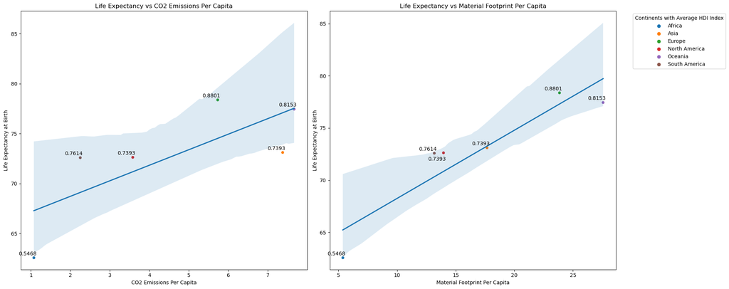

```python
fig, (ax1, ax2) = plt.subplots(1, 2, figsize=(20, 8))

#Life Expectancy vs CO2 Emissions Per Capita
sns.scatterplot(data=co2_footprint_capita, x='avg_co2_per_capita', y='avg_life_expectancy', hue='Continents', ax=ax1)
sns.regplot(data=co2_footprint_capita, x='avg_co2_per_capita', y='avg_life_expectancy', scatter=False, ax=ax1)
ax1.set_title('Life Expectancy vs CO2 Emissions Per Capita')
ax1.set_xlabel('CO2 Emissions Per Capita')
ax1.set_ylabel('Life Expectancy at Birth')
ax1.get_legend().remove()

#Life Expectancy vs Material Footprint Per Capita
sns.scatterplot(data=co2_footprint_capita, x='avg_footprint_per_capita', y='avg_life_expectancy', hue='Continents', ax=ax2)
sns.regplot(data=co2_footprint_capita, x='avg_footprint_per_capita', y='avg_life_expectancy', scatter=False, ax=ax2)
ax2.set_title('Life Expectancy vs Material Footprint Per Capita')
ax2.set_xlabel('Material Footprint Per Capita')
ax2.set_ylabel('Life Expectancy at Birth')
ax2.legend(title='Continents with Average HDI Index', bbox_to_anchor=(1.05, 1), loc=2)

for i in range(len(co2_footprint_capita)):
    ax1.annotate(
        f"{co2_footprint_capita['avg_hdi_index'].iloc[i]:.4f}",
        (co2_footprint_capita['avg_co2_per_capita'].iloc[i], co2_footprint_capita['avg_life_expectancy'].iloc[i]),
        textcoords="offset points",
        xytext=(5,5),
        ha='right'
    )
    offset_x, offset_y = 5, 5
    if i == 3:
        offset_x, offset_y = 5, -15
    ax2.annotate(
        f"{co2_footprint_capita['avg_hdi_index'].iloc[i]:.4f}",
        (co2_footprint_capita['avg_footprint_per_capita'].iloc[i], co2_footprint_capita['avg_life_expectancy'].iloc[i]),
        textcoords="offset points",
        xytext=(offset_x, offset_y),
        ha='right'
    )
plt.tight_layout()
plt.show()
```

#### Inference:

Using Seaborn, we visualized our data in the scatter plots here. These plots, generated from the query reveal, trends in life expectancy against environmental factors, distinguished by average HDI indexes across continents. The data visualized as scatter plots with trend lines depict the interaction between the chosen indicators, suggesting that higher emissions or material footprints do correspond to improved life expectancy. However there is slight variation in HDI scores but in general a higher CO2 emission and material footprint per capita do show a correlation. These insights derived from the joined datasets underscore the nuanced impact of environmental factors on human development, influenced by a range of socio-economic and policy variables unique to each region.

## Query 2:

```python
query_q3B = """
SELECT
    cc.Country,
    agg.Continents,
    agg.avg_hdi_index,
    agg.avg_life_expectancy,
    agg.avg_co2_per_capita,
    agg.avg_footprint_per_capita
FROM
    (SELECT
         country_continents.Continents,
         AVG(hdi_table7.HDI_index) AS avg_hdi_index,
         AVG(hdi_table1.life_expectancy_at_birth) AS avg_life_expectancy,
         AVG(hdi_table7.co2_per_capita) AS avg_co2_per_capita,
         AVG(hdi_table7.footprint_per_capita) AS avg_footprint_per_capita
     FROM
         hdi_table7
     INNER JOIN
         hdi_table1
     ON
         hdi_table7.country = hdi_table1.Country
     INNER JOIN
         country_continents
     ON
         hdi_table7.country = country_continents.Country
     GROUP BY
         country_continents.Continents
    ) AS agg
INNER JOIN
    country_continents AS cc
ON
    agg.Continents = cc.Continents
"""

co2_footprint_capita_country = pd.read_sql(query_q3B, engine)
co2_footprint_capita_country
```

|  | Country | Continents | avg_hdi_index | avg_life_expectancy | avg_co2_per_capita | avg_footprint_per_capita |
| --- | --- | --- | --- | --- | --- | --- |
| 0 | Mauritius | Africa | 0.546822 | 62.565584 | 1.075556 | 5.368889 |
| 1 | Seychelles | Africa | 0.546822 | 62.565584 | 1.075556 | 5.368889 |
| 2 | Algeria | Africa | 0.546822 | 62.565584 | 1.075556 | 5.368889 |
| 3 | Egypt | Africa | 0.546822 | 62.565584 | 1.075556 | 5.368889 |
| 4 | Tunisia | Africa | 0.546822 | 62.565584 | 1.075556 | 5.368889 |
| ... | ... | ... | ... | ... | ... | ... |
| 186 | Suriname | South America | 0.761400 | 72.584159 | 2.250000 | 13.170000 |
| 187 | Paraguay | South America | 0.761400 | 72.584159 | 2.250000 | 13.170000 |
| 188 | Guyana | South America | 0.761400 | 72.584159 | 2.250000 | 13.170000 |
| 189 | Bolivia (Plurinational State of) | South America | 0.761400 | 72.584159 | 2.250000 | 13.170000 |
| 190 | Venezuela (Bolivarian Republic of) | South America | 0.761400 | 72.584159 | 2.250000 | 13.170000 |

191 rows × 6 columns

### Query Explanation:

A similar query was also made for the purpose of building a Tableau geographical visualization. The only difference in this query was to add the country name so Tableau could group them into continents. This data offers the same insights as the Seaborn plot, however this offers a more visually interactive depiction of our results, as you will see below.

```python
%%html
<div class='tableauPlaceholder' id='viz1701388308636' style='position: relative'><noscript><a href='#'><img alt='Continental Overview of Human Development, Environmental Impact, and Life Expectancy ' src='https:&#47;&#47;public.tableau.com&#47;static&#47;images&#47;YC&#47;YC3X82SGZ&#47;1_rss.png' style='border: none' /></a></noscript><object class='tableauViz'  style='display:none;'><param name='host_url' value='https%3A%2F%2Fpublic.tableau.com%2F' /> <param name='embed_code_version' value='3' /> <param name='path' value='shared&#47;YC3X82SGZ' /> <param name='toolbar' value='yes' /><param name='static_image' value='https:&#47;&#47;public.tableau.com&#47;static&#47;images&#47;YC&#47;YC3X82SGZ&#47;1.png' /> <param name='animate_transition' value='yes' /><param name='display_static_image' value='yes' /><param name='display_spinner' value='yes' /><param name='display_overlay' value='yes' /><param name='display_count' value='yes' /><param name='language' value='en-US' /><param name='filter' value='publish=yes' /></object></div>                <script type='text/javascript'>                    var divElement = document.getElementById('viz1701388308636');                    var vizElement = divElement.getElementsByTagName('object')[0];                    vizElement.style.width='100%';vizElement.style.height=(divElement.offsetWidth*0.75)+'px';                    var scriptElement = document.createElement('script');                    scriptElement.src = 'https://public.tableau.com/javascripts/api/viz_v1.js';                    vizElement.parentNode.insertBefore(scriptElement, vizElement);                </script>
```

[figure not shown]

#### Inference:

Again, our findings indicate a clear trend: environmental factors do serve as predictors for life expectancy and HDI. However, we have to keep in mind the underlying factors that contribute to these indicators. Higher CO2 emissions and material footprints often reflect a country's industriousness and development level, which in turn are associated with better quality healthcare systems and higher living standards. Although, these factors may lead to both higher life expectancy and HDI indices, like what’d you see in more developed countries. So, while these environmental metrics are significant, they are part of a larger narrative.

# Conclusion and Future Scope

In conclusion, our investigation into the guiding questions has yielded insightful correlations and disparities in the realm of human development. The data indicates that Africa and Asia have experienced the most significant average percentage increases in HDI, reflecting varying paces of socio-economic progress compared to regions like Oceania, North America, and Europe, where changes were less pronounced. Regarding wage equity, our findings from the second guiding question highlight a persistent wage gap between genders, even when educational achievements are similar, signaling systemic inequality in pay structures across the globe. Moreover, our third guiding question reveals a telling relationship between human development and gender inequality: higher HDI correlates with lower gender disparity, with increased gender inequality adversely affecting the estimated gross national income for both men and women. Lastly, the trends from our fourth inquiry suggest that while CO2 emissions and material footprint serve as indicators of life expectancy and HDI, they are not sole determinants. These attributes are shaped by a complex interplay of environmental, socio-economic, and policy factors. Collectively, these insights emphasize the need for nuanced approaches to policy and development that address both human and environmental well-being.

In light of our findings, which illuminate areas ready for policy intervention, particularly in education and gender equality, there lies a path forward to mitigate the wage gap and reinforce human development. Future projects could use this data to dive deeper into the relationships between economic growth, environmental sustainability, and overall human well-being. It is essential to expand our inquiry to understand how to foster economic progress without compromising the health of our planet or the equity among its inhabitants. By doing so, we can aim to craft policies that not only support sustainable development but also ensure that such development is inclusive, equitable, and reflective of the needs of populations across the globe.

# Discussion

### TEAM MEMBER: PRATEEK KAUSHIK

In the intricate process of cleaning Table 1 data sourced from 'HDR21-22_Statistical_Annex_HDI_Table.xlsx,' my contribution extended beyond meticulous Python scripting to encompass the realm of Tableau visualizations. As the steward of the Tableau landscape in our project, I crafted pivotal visualizations that served as compass points for our team's exploration into human development dynamics. The journey commenced with ensuring data integrity – from aligning country names for consistency to purging any extraneous information. This laid the groundwork for Table 1's role as a linchpin, seamlessly interfacing with other datasets. The impact reverberated across analyses, influencing not just the specifics of HDI but also cascading into the realms explored by fellow team members.

Throughout this project, I gained profound insights into the intricate nature of human development dynamics. Navigating through the nuances of data cleaning, I not only refined my Python skills but also delved into the realm of Tableau, honing my abilities to convey complex datasets visually. The experience served as a pivotal learning curve, demonstrating the symbiotic relationship between meticulous data preparation and the transformative power of visualization. Looking forward, I envision applying the skills acquired in this project to future endeavors, exploring avenues where data analysis and visualization converge. The role of Tableau in distilling complex datasets into visually compelling narratives has sparked a keen interest, prompting a desire to delve deeper into advanced visualization techniques. In future projects, I aspire to blend my proficiency in Python data wrangling with advanced Tableau capabilities, creating comprehensive analytical frameworks.

Reflecting on this collaborative effort, I recognize the value of interactive presentations to engage audiences. In future undertakings, I aim to invest more effort in fostering audience interaction, realizing the potential to make our analyses more impactful. The project has illuminated my path toward a multifaceted skill set, combining technical data skills with effective communication and presentation abilities. As I contemplate future prospects, the prospect of incorporating additional indicators into the HDI and exploring advanced visualization tools like Power BI aligns with my aspiration to continually enhance my skill set. The robust foundation laid during this project opens avenues to delve into diverse indicators, providing a holistic view of human development. The learning from this experience extends beyond technical skills, embracing a broader perspective on the intersection of data, development, and effective communication.

In essence, this project has not only refined my technical skills but has also laid the groundwork for a holistic understanding of the intricate dynamics that underpin human development. As I navigate future opportunities, I carry forward the lessons learned, aiming to contribute meaningfully to endeavors that bridge the realms of data analysis, visualization, and impactful communication.

### TEAM MEMBER: PRASHANT DHUNGANA

Through the exploration of the Human Development Index topic in this project, I gained valuable insights and acquired various technical skills, specifically using Tableau to visualize our data. During the preliminary analysis of Table 2, I delved into HDI trends across different continents and identified key factors influencing HDI increases. It was particularly intriguing to observe that no country worldwide experienced a decrease in HDI value within a 10-year period. This project expanded my understanding of factors beyond education, health, and living standards that contribute to human development progress.

Refelcting on our project, I recognize the opportunity to enhance the interactivity of our presentation for the audience. While showcasing analysis results is crucial, making the presentation more engaging can significantly amplify the impact of our group's work. In future projects, I aspire to collaborate more closely with team members to achieve this goal.

Looking ahead, I am eager to delve deeper into this topic. I envision incorporating data on the three dimensions used to compute the Human Development Index for each country within annual periods. This approach will allow me to identify the most significant factors contributing to the increase or decrease of HDI values on a yearly basis, providing a more detailed and nuanced understanding of human development dynamics.

### TEAM MEMBER: NISHA PILLAI

Through this project, I gained insights into the Human Development Index (HDI) and its constituent factors. While working with the Gender Development Index table to address our guiding question, I discovered that despite a country's high development, disparities in specific factors persist. Ensuring equality among people is crucial for collective human progress globally. Identifying the 28 countries with wage gaps proved that educational levels do not guarantee equal pay. Cultivating a shift in mindset is crucial for ensuring gender parity in compensation, acknowledging talent regardless of gender.

This project provided an opportunity to delve into SQL queries using the Pandas framework, expanding my skill set significantly. I familiarized myself with SQL join queries, aggregate functions, diverse SQL clauses, table management, and the INSERT function,in a productive way. Utilizing Tableau for visualizations helped me learn a new software to generate interactive visualization for the output tables generated using SQL queries.

I intend to apply these newly acquired skills to future projects. Additionally, I am keen on furthering my expertise in both SQL and NoSQL databases. To extend this project in the future incorporating additional indicators like —healthcare access, vaccination coverage, healthcare expenditure, student-teacher ratios, technology accessibility, housing access, crime rates—into the HDI could yield insightful conclusions. Exploring MongoDB for handling unstructured data accompanying these indicators will enhance our understanding of a country's growth potential .Analyzing diverse indicators promises valuable insights into a country's development trajectory.

### TEAM MEMBER: MARIYA MATHEWS

In the context of overall country development, Gender Inequality, although not directly factored into the comprehensive development metric, demonstrates a robust correlation with the country's overall development. As a nation progresses, the gender gap tends to decrease, and concurrently, the estimated national gross income for both males and females sees an upward trend. It's crucial to emphasize that correlation does not imply causation.

Technologically, I acquired practical skills in utilizing Tableau for effective data visualization. My proficiency in SQL queries, table interactions, and data merging was significantly enhanced throughout the project.

Reflecting on the project's evolution, if I were to initiate it anew, I would focus on normalizing the tables and implementing indexes, primary, and foreign keys for each table. Additionally, exploring Power BI as an alternative for visualization could offer valuable insights.

Given the substantial negative correlation observed between HDI and GII, a deeper investigation into specific correlations between individual factors of HDI and GII becomes intriguing. Unveiling which components of HDI exhibit strong correlations with particular aspects of GII is pivotal. To achieve this, acquiring more granular details on the components of HDI and subsequently exploring the GII factors influencing them would be essential. This approach, grounded in data-driven insights, can unveil the factors that wield the most significant influence rather than relying on general assumptions.

### TEAM MEMBER: ARTEEN RAFIEI

Throughout this project, I gained a significant understanding of the complex nature of Human Development Index (HDI) and the intricacies of SQL querying. Initially, I viewed HDI as a relatively straightforward measure, but as I delved into the data and the analytical process, I realized its complexity and the interdependence with various societal and environmental factors. SQL querying emerged as an invaluable skill, allowing me to manipulate and analyze large datasets efficiently. My proficiency in SQL grew as I learned to join tables, execute aggregate functions, and group data to uncover regional trends in human development.

The project also highlighted the importance of considering a wide array of indicators when assessing HDI. While CO2 emissions and material footprint provide insights into environmental pressures, they represent only a slice of the developmental picture. Life expectancy and HDI are influenced by an intricate web of variables, and future analyses could benefit from including measures of industriousness, productivity, and other contributions by individual countries. Such factors could offer a more comprehensive understanding of the determinants of human development.

Reflecting on the technologies and techniques used, I see potential for integrating advanced data modelling tools or machine learning algorithms to predict and analyze HDI with greater precision. For instance, employing predictive analytics could uncover hidden patterns and relationships within the data that are not immediately obvious through traditional methods. In future extensions of this project, I would like to explore these advanced techniques to build more robust models that can encapsulate the complexities of human development. This will enable us to not only understand current HDI standings but also to forecast future trends and potentially guide policy-making decisions that aim to enhance human well-being globally.

# References

[1] U. Nations, “Human Development Index,” United Nations. Available: https://hdr.undp.org/data-center/human-development-index. [Accessed: Nov. 06, 2023]

[2] U. Nations, “Terms of use,” United Nations. Available: https://hdr.undp.org/terms-use. [Accessed: Nov. 06, 2023]

[3] B. Herre, P. Arriagada, and M. Roser, “The Human Development Index and related indices: what they are and what we can learn from them,” Our World in Data, Nov. 2023, Available: https://ourworldindata.org/human-development-index. [Accessed: Nov. 06, 2023]

[4] “What Is the Human Development Index (HDI)?,” Investopedia. Available: https://www.investopedia.com/terms/h/human-development-index-hdi.asp. [Accessed: Nov. 06, 2023]

[5] G. Dongre, “What is Human Development Index?,” Medium, Jun. 12, 2021. Available: https://ganeshdongre.medium.com/what-is-human-development-index-9f2f991dfd88. [Accessed: Nov. 06, 2023]

[6] “Measuring development | Learn economics.” Available: https://www.learn-economics.co.uk/Measuring-development.html. [Accessed: Nov. 06, 2023]

[7] “Build a Basic View to Explore Your Data.” Available: https://help.tableau.com/current/pro/desktop/en-us/getstarted_buildmanual_ex1basic.htm. [Accessed: Nov. 06, 2023]

[8] “How to Automate Data Cleaning in Python?,” GeeksforGeeks, May 31, 2023. Available: https://www.geeksforgeeks.org/how-to-automate-data-cleaning-in-python/.%5BAccessed: Nov. 06, 2023]

[9] E. Ortiz-Ospina and M. Roser, “Economic Inequality by Gender,” Our World in Data, Mar. 2018, Available: https://ourworldindata.org/economic-inequality-by-gender [Accessed: Nov. 06, 2023]

# Appendix

```python
#Library Used for the Project.

import pandas as pd
import sqlalchemy as sq
from sqlalchemy import inspect
import seaborn as sns
import matplotlib.pyplot as plt
import geopandas as gpd
```

```python
# Connect to local database
engine = sq.create_engine('mysql+mysqlconnector://l01-7:PlOPL4qfvFu7I@datasciencedb2.ucalgary.ca/l01-7')

# Create an inspector object
inspector = inspect(engine)

# Retrieve a list of all table names
table_names = inspector.get_table_names()
print("Tables in the database:")
for table in table_names:
    print(table)

# Close the connection
#engine.dispose()
```

```python
#Code includes cleaning of all the tables used in the project.

#importing 5 excel sheets
#Table 1

hdi_data = pd.read_excel('HDR21-22_Statistical_Annex_HDI_Table.xlsx', sheet_name = 'Table 1', header = 3)


#Removing the rows that act as header by dropping all the rows that has missing HDI rank
cleaned_hdi_data=hdi_data.dropna(subset=["Unnamed: 0"])

#Renaming the columns
column_names={"Unnamed: 0":"HDI Rank",
    "Unnamed: 1":"Country",
    "Unnamed: 2":"Human Development Index (Value) 2021",
    "Unnamed: 4":"Life expectancy at birth (years) 2021",
    "Unnamed: 6":"Expected years of schooling (years) 2021",
    "Unnamed: 8":"Mean years of schooling (years) 2021",
    "Unnamed: 10":"Gross national income (GNI) per capita (PPP $) 2021",
    "Unnamed: 12":"GNI per capita rank minus HDI rank 2021",
    "Unnamed: 14":"HDI rank 2020"}
cleaned_hdi_data=cleaned_hdi_data.rename(columns=column_names)



cleaned_hdi_data = cleaned_hdi_data.drop(columns = ['Unnamed: 3', 'Unnamed: 5', 'Unnamed: 7', 'Unnamed: 9', 'Unnamed: 11', 'Unnamed: 13'])


#Removing the first row with duplicate headers
cleaned_hdi_data=cleaned_hdi_data.drop(cleaned_hdi_data.index[0])


#Replace the ".." values in data with NAN
cleaned_hdi_data_replace=cleaned_hdi_data.replace("..",pd.NA)

hdi_column_check_table1=["HDI Rank","Country","Human Development Index (Value) 2021","Life expectancy at birth (years) 2021","Expected years of schooling (years) 2021","Mean years of schooling (years) 2021","Gross national income (GNI) per capita (PPP $) 2021","GNI per capita rank minus HDI rank 2021", "HDI rank 2020"]
missing_hdi_table1=cleaned_hdi_data_replace[cleaned_hdi_data_replace[hdi_column_check_table1].isnull().any(axis=1)]


#Dropping all the countries that has any missing HDI values in any years beteen 1990-2021
clean_hdi_no_missing_data_table1=cleaned_hdi_data_replace.dropna(subset=hdi_column_check_table1)

#Correcting the formatting of country names
clean_hdi_no_missing_data_table1.loc[clean_hdi_no_missing_data_table1["Country"]=="Hong Kong, China (SAR)","Country"]= "Hong Kong"
clean_hdi_no_missing_data_table1.loc[clean_hdi_no_missing_data_table1["Country"]=="Türkiye","Country"]= "Turkey"
clean_hdi_no_missing_data_table1.loc[clean_hdi_no_missing_data_table1["Country"]=="Côte d'Ivoire","Country"]= "Ivory Coast"

#Saving the cleaned data into a new csv file
clean_hdi_no_missing_data_table1.to_csv("HDI_Table_1.csv",index=False)

#Loading the new cleaned data csv file
cleaned_hdi_table1=pd.read_csv("HDI_Table_1.csv")




#Table 2
#Opening the excel file by skipping the initial rows that do not contain data
hdi_data=pd.read_excel("HDR21-22_Statistical_Annex_HDI_Trends_Table.xlsx",sheet_name="Table 2",header=3)

#Removing the rows that act as header by dropping all the rows that has missing HDI rank
clean_hdi_data=hdi_data.dropna(subset=["Unnamed: 0"])

#Renaming the columns
column_names={"Unnamed: 0":"HDI Rank",
    "Unnamed: 1":"Country",
    "Value":"HDI 1990",
    "Unnamed: 4":"HDI 2000",
    "Unnamed: 6":"HDI 2010",
    "Unnamed: 8":"HDI 2015",
    "Unnamed: 10":"HDI 2018",
    "Unnamed: 12":"HDI 2019",
    "Unnamed: 14":"HDI 2020",
    "Unnamed: 16":"HDI 2021",
    "Unnamed: 18": "Change in HDI Rank 2015-2021",
    "(%)": "Average Annual Growth 1990-2000 (%)",
    "Unnamed: 22": "Average Annual Growth 2000-2010 (%)",
    "Unnamed: 24": "Average Annual Growth 2010-2021 (%)",
    "Unnamed: 26": "Average Annual Growth 1990-2021 (%)"}
clean_hdi_data=clean_hdi_data.rename(columns=column_names)

#Removing the first row with duplicate headers
clean_hdi_data=clean_hdi_data.drop(clean_hdi_data.index[0])

#Dropping the "Unnamed" columns with NAN values
columns_keep=[col for col in clean_hdi_data.columns if not col.startswith("Unnamed")]
clean_hdi_data=clean_hdi_data[columns_keep]

#Replace the ".." values in data with NAN
clean_hdi_data_replace=clean_hdi_data.replace("..",pd.NA)

#Checking for any missing HDI values for Countries between 1990-2021
hdi_column_check=["HDI 1990","HDI 2000","HDI 2010","HDI 2015","HDI 2018","HDI 2019","HDI 2020","HDI 2021"]
missing_hdi=clean_hdi_data_replace[clean_hdi_data_replace[hdi_column_check].isnull().any(axis=1)]

#Dropping all the countries that has any missing HDI values in any years beteen 1990-2021
clean_hdi_no_missing_data=clean_hdi_data_replace.dropna(subset=hdi_column_check)

#Correcting the formatting of country names
clean_hdi_no_missing_data.loc[clean_hdi_no_missing_data["Country"]=="Hong Kong, China (SAR)","Country"]= "Hong Kong"
clean_hdi_no_missing_data.loc[clean_hdi_no_missing_data["Country"]=="Türkiye","Country"]= "Turkey"
clean_hdi_no_missing_data.loc[clean_hdi_no_missing_data["Country"]=="Côte d'Ivoire","Country"]= "Ivory Coast"

#Saving the cleaned data into a new csv file
clean_hdi_no_missing_data.to_csv("Cleaned_HDI_Table_2.csv",index=False)

#Loading the new cleaned data csv file
cleaned_hdi_table2=pd.read_csv("Cleaned_HDI_Table_2.csv")



#Table 4

#Opening the excel file for dataset for table 4
gdi_data=pd.read_excel("HDR21-22_Statistical_Annex_GDI_Table.xlsx",sheet_name="Table 4",header=3)

#Finding the percentage of missing values in each column
features=gdi_data.columns.values
missing_val=gdi_data.isnull().sum()
non_missing_val= gdi_data.notnull().sum()
total_val=gdi_data.shape[0]

#Calculating percentage
percentage_missing=missing_val/total_val*100

#Dropping a column if the percentage of missing value is above 60% since these values do not matter they are mostly NAN values
threshold=60

#dropping the columns that fit the threshold
drop_columns = percentage_missing[percentage_missing >= threshold].index
gdi_data.drop(columns=drop_columns, inplace=True)

#drop all the rows that has missing HDI rank.
new_gdi_data=gdi_data.dropna(subset=["Unnamed: 0"])

#creating new column names
column_names={"Unnamed: 0":"HDI Rank",
    "Unnamed: 1":"Country",
    "Gender Development Index":"Gender Development Index Value",
    "Unnamed: 4":"Gender Development Index Value Group",
    "Human Development Index":"Human Development Index Female(value)",
    "Unnamed: 8":"Human Development Index Male(value)",
    "Life expectancy at birth":"Life expectancy at birth Female(years)",
    "Unnamed: 12":"Life expectancy at birth Male(years)",
    "Expected years of schooling":"Expected years of schooling Female(years)",
    "Unnamed: 16":"Expected years of schooling Male(years)",
    "Mean years of schooling":"Mean years of schooling Female(years)",
    "Unnamed: 20":"Mean years of schooling Male(years)",
    "Estimated  gross national income per capita":"Estimated gross national income per capita Female(2017 PPP $)",
    "Unnamed: 24": "Estimated gross national income per capita Male(2017 PPP $)"}
new_gdi_data=new_gdi_data.rename(columns=column_names)
```

```python
#Removing the first row with duplicate headers
new_gdi_data=new_gdi_data.drop(new_gdi_data.index[0])

#Replace the ".." values in data with NAN
new_gdi_data_replace=new_gdi_data.replace("..",pd.NA)

#Check for any missing values accross the table
gdi_column_check=["Gender Development Index Value","Gender Development Index Value Group","Human Development Index Female(value)","Human Development Index Male(value)","Life expectancy at birth Female(years)","Life expectancy at birth Male(years)","Expected years of schooling Female(years)","Expected years of schooling Male(years)","Mean years of schooling Female(years)","Mean years of schooling Male(years)","Estimated gross national income per capita Female(2017 PPP $)","Estimated gross national income per capita Male(2017 PPP $)"]
missing_gdi=new_gdi_data_replace[new_gdi_data_replace[gdi_column_check].isnull().any(axis=1)]

#Dropping all the countries that has any missing values
new_gdi_no_missing_data=new_gdi_data_replace.dropna(subset=gdi_column_check)

#Correcting the formatting of country names.(we will be keeping the country names same throuughout all the tables individually)
new_gdi_no_missing_data.loc[new_gdi_no_missing_data["Country"]=="Hong Kong, China (SAR)","Country"]= "Hong Kong"
new_gdi_no_missing_data.loc[new_gdi_no_missing_data["Country"]=="Türkiye","Country"]= "Turkey"
new_gdi_no_missing_data.loc[new_gdi_no_missing_data["Country"]=="Côte d'Ivoire","Country"]= "Ivory Coast"

#Saving the cleaned data into a new csv file
new_gdi_no_missing_data.to_csv("New_GDI_Table_4.csv",index=False)

#Loading the new csv file which was cleaned for firing SQL queries
new_gdi_table4=pd.read_csv("New_GDI_Table_4.csv")




#table 5

#Data Cleaning of table 5:

# Excel file name
excel_file_name = 'HDR21-22_Statistical_Annex_GII_Table.xlsx'
excel_sheet_name = "Table 5"
#using fourth row as header(pandas count rows from 0)
excel_GII_df = pd.read_excel(excel_file_name,sheet_name =excel_sheet_name, header=[3])

# Rename the columns from or using the row 1 (Row starts with index 0)
#using some strings for the header name. Assigning to a string rather than hardcoding in the function
underscore_str = '_'
female_str = 'Female'
sec_education_str = 'Population_Atleast_Sec_Education'
# new column names involve combinations of existing column names, underscores, and values from specific rows in the DataFrame.
# The code is used to make the column names more descriptive .
#HDI rank and Country column names (From row 1) are to be added to column 0 and 1
#all the other column names should be appended with strings in row 1
excel_GII_df.rename(columns={excel_GII_df.columns[0]: excel_GII_df.iloc[1,0],
                             excel_GII_df.columns[1]: excel_GII_df.iloc[1,1],
                             excel_GII_df.columns[2]:excel_GII_df.columns[2]+underscore_str+excel_GII_df.iloc[0,2],
                             excel_GII_df.columns[4]: excel_GII_df.columns[2]+underscore_str+ excel_GII_df.iloc[0,4],
                             excel_GII_df.columns[10]:excel_GII_df.columns[10]+underscore_str+female_str,
                             excel_GII_df.columns[12]:sec_education_str+ underscore_str + excel_GII_df.iloc[1,12],
                             excel_GII_df.columns[14]:sec_education_str+ underscore_str  + excel_GII_df.iloc[1,14],
                             excel_GII_df.columns[16]:excel_GII_df.columns[16]+underscore_str+excel_GII_df.iloc[1,16],
                             excel_GII_df.columns[18]:excel_GII_df.columns[16]+underscore_str+excel_GII_df.iloc[1,18]
                            },
                             inplace=True)

# Filter columns that start with "Unnamed".Now we know that the unnamed columns does not hold any information, we delete those columns
columns_to_drop = [col for col in excel_GII_df.columns if col.startswith('Unnamed')]
# Drop the selected columns
excel_GII_df.drop(columns=columns_to_drop, inplace=True)

# Drop columns where all values are NaN.(Specifically To remove the last column)
excel_GII_df.dropna(axis=1, how='all', inplace=True)

#Drop first rows as it includes only header information that we have already extrcated
excel_GII_df.drop(index=excel_GII_df.index[:3], inplace=True)

#The 'country' column includes names of human development groups in certain rows, indicating that the subsequent rows pertain to
#the specified group. So we create another column to hold this information
# Identify rows where 'Country' contains the group name HUMAN DEVELOPMENT
group_name = 'HUMAN_DEVELOPMENT_GROUP'
country_name = excel_GII_df.columns[1]
group_rows = excel_GII_df[country_name].str.contains('HUMAN DEVELOPMENT', na=False)
# Create a new column 'HUMAN_DEVELOPMENT_GROUP' with the corresponding group name for each row
excel_GII_df[group_name] = excel_GII_df.loc[group_rows, country_name]
# Forward fill the NaN values in the 'HUMAN_DEVELOPMENT_GROUP' column to propagate the groupname
excel_GII_df[group_name].fillna(method='ffill', inplace=True)

#now we can delete the rows where "Country" column contains the groupname
# Identify rows where 'country' is the same as the group name
rows_to_delete = excel_GII_df[country_name] == excel_GII_df[group_name]
# Delete the identified rows
excel_GII_df.drop(excel_GII_df[rows_to_delete].index, inplace=True)

# Function to clean and format column names
def clean_column_name(col_name):
    col_name = col_name.lower()  # Convert to uppercase
    col_name = col_name.replace(' ', '_')  # Replace spaces with underscores useful in wriitng queries
    return col_name

# Apply the function to each column name
excel_GII_df.columns = [clean_column_name(col) for col in excel_GII_df.columns]

#Replace the ".." values in data with NAN
excel_GII_df.replace(["..","—"],pd.NA,inplace =True)
#Remove all the rows if the Gender Inequality rank value is
#null or empty as our main focus is on GII value and rank
# Drop rows where 'GENDER_INEQUALITY_INDEX_RANK' is null
excel_GII_df.dropna(subset=['gender_inequality_index_rank'], inplace=True)
```

```python
#Correcting the formatting of country names
excel_GII_df.loc[excel_GII_df["country"]=="Hong Kong, China (SAR)","country"]= "Hong Kong"
excel_GII_df.loc[excel_GII_df["country"]=="Türkiye","country"]= "Turkey"
excel_GII_df.loc[excel_GII_df["country"]=="Côte d'Ivoire","country"]= "Ivory Coast"

#Saving the cleaned data into a csv file for loading to SQL
excel_GII_df.to_csv("Gender_Inequality_Index.csv",index=False)

#reading the csv
csv_gender_inequality_index = pd.read_csv("Gender_Inequality_Index.csv")



#table 7

#Load the CSV file, considering headers are on the 6th row (index 5)
uncleaned_table7 = pd.read_excel("HDR21-22_Statistical_Annex_PHDI_Table.xlsx", sheet_name = 'Table 7',header=5)

#Replace ".." with NaN in the entire dataframe
uncleaned_table7.replace("..", pd.NA, inplace=True)

#Drop all rows without an HDI rank
cleaning_table7 = uncleaned_table7.dropna(subset=['HDI rank'])

#Drop all empty columns
cleaning_table7 = cleaning_table7.dropna(axis=1, how='all')

#Drop rows that are completely empty or contain NaN in any column
cleaning_table7 = cleaning_table7.dropna(how='any')

column_names = {"HDI rank":"HDI_rank",
    "Human Development Index (HDI) ":"HDI_index",
    "Planetary pressures-adjusted HDI (PHDI)":"PHDI",
    "Difference from HDI value (%)":"Difference_from_HDI_perc",
    "Difference from HDI rank":"Difference_from_HDI_rank",
    "Adjustment factor for planetary pressures":"adj_factor",
    "Carbon dioxide emissions per capita (production)":"co2_per_capita",
    "Carbon dioxide emissions (production) index":"co2_prod_index",
    "Material footprint per capita":"footprint_per_capita",
    "Material footprint index":"footprint_index"}

cleaning_table7 = cleaning_table7.rename(columns=column_names)

cleaning_table7.to_csv("cleaned_table7.csv",index=False)

cleaned_table7 = pd.read_csv("cleaned_table7.csv")

#country contients csv
#Load the continent_country table in the database
continents_table=pd.read_csv("country_continents_table.csv")
```

##### Loading CSV to SQL Table

```python
# connect to  database;
engine = sq.create_engine('mysql+mysqlconnector://l01-7:PlOPL4qfvFu7I@datasciencedb2.ucalgary.ca/l01-7')


# write dataframe of table 1 into a SQL table
try:
    cleaned_hdi_table1.to_sql('hdi_table1', engine , index=False, if_exists='fail')
except Exception as e:
    print(f"Error: {e}")


# write dataframe of table 2 into a SQL table
try:
    cleaned_hdi_table2.to_sql('hdi_table2', engine , index=False, if_exists='fail')
except Exception as e:
    print(f"Error: {e}")

# write dataframe of table 4 into a SQL table
try:
    new_gdi_table4.to_sql('hdi_table4', engine , index=False, if_exists='fail')
except Exception as e:
    print(f"Error: {e}")

# write  dataframe of table 5 into a SQL table
try:
    csv_gender_inequality_index.to_sql('hdi_table5', engine, index=False, if_exists='fail')
except Exception as e:
    print(f"Error: {e}")
#Read the table to dataframe


# write dataframe of table 7 into a SQL table
try:
    cleaned_table7.to_sql('hdi_table7', engine, index=False, if_exists='fail')
except Exception as e:
    print(f"Error: {e}")

# write dataframe of country contients csv to SQL table
try:
    continents_table.to_sql("country_continents",engine, index=False, if_exists='fail')
except Exception as e:
    print(f"Error: {e}")
```

```
Error: Table 'hdi_table1' already exists.
Error: Table 'hdi_table2' already exists.
Error: Table 'hdi_table4' already exists.
Error: Table 'hdi_table5' already exists.
Error: Table 'hdi_table7' already exists.
Error: Table 'country_continents' already exists.
```

```python
#To close connection
engine.dispose()
```